# 001038_DombeckLab_001038_demo_ipynb

## Installing requirements

The cell below installs every Python package needed to run this notebook, at fully pinned versions, using [`uv`](https://github.com/astral-sh/uv) for fast resolution. In Colab the cell is collapsed by default — click the ▶ button to run it.

```python
# install cell skipped during CI (deps preinstalled into system Python)
```

> **⚠️ Restart runtime after install**

> The install may upgrade packages already loaded in the kernel. Go to **Runtime → Restart session**, then **Run all cells below** (skip this install cell on re-run).

# Azcorra 2023 demo

This tutorial demonstrates how to access an NWB file from the [DANDI:001038](https://dandiarchive.org/dandiset/001038/draft) dandiset using `pynwb` and `dandi`.

This session contains fiber photometry recordings from head-fixed mice running on a treadmill while receiving rewards and aversive air puffs in order to analyze differences or similarities in functional responses of different subtypes of striatonigral dopamine neurons.

Contents:

- Streaming an NWB file
- Access Subject Metadata
- Access raw fiber photometry data
- Access processed fiber photometry data
- Access behavior
- View NWB file

# Streaming an NWB file

This section demonstrates how to access the files on the [DANDI Archive](https://dandiarchive.org) without downloading them. Based on the [Streaming NWB files](https://pynwb.readthedocs.io/en/stable/tutorials/advanced_io/streaming.html) tutorial from [PyNWB](https://pynwb.readthedocs.io/en/stable/#).

An NWBFile represents a single session of an experiment. Each NWBFile must have a `session description`, `identifier`, and `session start time`.

The `dandi.dandiapi.DandiAPIClient` can be used to get the S3 URL of the NWB file stored in the DANDI Archive.

```python
from dandi.dandiapi import DandiAPIClient

client = DandiAPIClient.for_dandi_instance("dandi")

dandiset_id = "001038"
file_path = "sub-VGlut-A997/sub-VGlut-A997_ses-20200205-0001.nwb"

with DandiAPIClient() as client:
    asset = client.get_dandiset(dandiset_id, 'draft').get_asset_by_path(file_path)
    s3_url = asset.get_content_url(follow_redirects=1, strip_query=True)
```

We will use `remfile` for streaming the file. You can read more about `remfile` at [this tutorial section](https://pynwb.readthedocs.io/en/stable/tutorials/advanced_io/streaming.html#method-3-remfile).

```python
import h5py
from pynwb import NWBHDF5IO
import remfile

# We stream the file using remfile and open it with h5py and pynwb
file = remfile.File(s3_url)
h5_file = h5py.File(file, "r")

io = NWBHDF5IO(file=h5_file, load_namespaces=True)
nwbfile = io.read()
nwbfile
```

root (NWBFile)

session_description: This session contains fiber photometry recordings from head-fixed mice running on a treadmill while receiving rewards and aversive air puffs in order to analyze differences or similarities in functional responses of different subtypes of striatonigral dopamine neurons.

identifier: d621fd32-9ad0-4120-a90e-6cc9ed546069

**session_start_time**

2020-02-05 00:00:00-06:00

**timestamps_reference_time**

2020-02-05 00:00:00-06:00

**file_create_date**

**0**

2024-07-11 16:37:31.836613+02:00

**experimenter**

('Azcorra, Maite',)

**related_publications**

('https://doi.org/10.1038/s41593-023-01401-9',)

**acquisition**

**AirPuff (TimeSeries)**

starting_time: 0.0

rate: 4000.2000543686745

resolution: -1.0

comments: no comments

description: The raw voltage trace from the air puff stimulus sensor collected at 4000 Hz by Picoscope.

conversion: 1.0

offset: 0.0

unit: Volts

**data**

HDF5 dataset

| Data type | float32 |
| --- | --- |
| Shape | (6761014,) |
| Array size | 25.79 MiB |
| Chunk shape | (2500000,) |
| Compression | gzip |
| Compression opts | 4 |
| Uncompressed size (bytes) | 27044056 |
| Compressed size (bytes) | 8128605 |
| Compression ratio | 3.327023025476081 |

starting_time_unit: seconds

**FiberPhotometryResponseSeries (FiberPhotometryResponseSeries)**

starting_time: 0.0

rate: 100.0

resolution: -1.0

comments: no comments

description: Raw green fluorescence collected during 470 nm illumination re-binned to 100 Hz and acquired with one or two optical fibers.

conversion: 1.0

offset: 0.0

unit: n.a.

**data**

HDF5 dataset

| Data type | float64 |
| --- | --- |
| Shape | (169024, 2) |
| Array size | 2.58 MiB |
| Chunk shape | (169024, 2) |
| Compression | gzip |
| Compression opts | 4 |
| Uncompressed size (bytes) | 2704384 |
| Compressed size (bytes) | 1137393 |
| Compression ratio | 2.377704100517587 |

starting_time_unit: seconds

**fiber_photometry_table_region (DynamicTableRegion)**

description: source fibers

**table (FiberPhotometryTable)**

description: Contains the metadata for the fiber photometry experiment.

**columns**

**location**

Location of fiber.

**indicator**

Link to the indicator object.

**optical_fiber**

Link to the optical fiber device.

**excitation_source**

Link to the excitation source device.

**photodetector**

Link to the photodetector device.

**dichroic_mirror**

Link to the dichroic mirror device.

**fiber_depth_in_mm**

The depth of the optical fiber in the unit of millimeters.

**baseline_fluorescence**

The baseline fluorescence value for each fiber.

**normalized_fluorescence**

The normalized fluorescence value for each fiber.

**recording_target_type**

Defines whether recordings are made in axons vs cell bodies.

**signal_to_noise_ratio**

The signal to noise ratio for each fiber.

**cross_correlation_with_acceleration**

The cross-correlation between ΔF/F and acceleration.

**coordinates**

Fiber placement in stereotactic coordinates (AP, ML, DV) mm relative to Bregma.

**emission_filter**

Link to the emission filter device.

**excitation_filter**

Link to the excitation filter device.

**table**

| id | location | indicator | optical_fiber | excitation_source | photodetector | dichroic_mirror | fiber_depth_in_mm | baseline_fluorescence | normalized_fluorescence | recording_target_type | signal_to_noise_ratio | cross_correlation_with_acceleration | coordinates | emission_filter | excitation_filter |
| --- | --- | --- | --- | --- | --- | --- | --- | --- | --- | --- | --- | --- | --- | --- | --- |
| 0 | SNc | GCaMP6f abc.Indicator at 0x139697612880736\nFields:\n injection_coordinates_in_mm: [-3.25 1.55 -3.8 ]\n injection_location: SNc\n label: AAV-GCaMP6f\n | Fiber1 abc.OpticalFiber at 0x139697608624176\nFields:\n core_diameter_in_um: 200.0\n description: The optical fiber used to record the GCaMP fluorescence from the SNc brain region.\n manufacturer: Dor… | ExcitationSource470 abc.ExcitationSource at 0x139697608510672\nFields:\n description: Blue excitation light (470 nm LED, Thorlabs, M70F3) and violet excitation light (for the isosbestic control)\nwere… | PhotodetectorPMT abc.Photodetector at 0x139697608624512\nFields:\n description: Hamamatsu GaAsP photomultiplier tube (signal amplified using Stanford Research Systems SR570 preamplifier).\n detected_w… | DichroicMirror abc.DichroicMirror at 0x139697608623168\nFields:\n cut_on_wavelength_in_nm: 505.0\n description: The dichroic mirror used to separate green fluorescence from the excitation light.\n man… | 3.6 | 1.041767 | 0.686421 | cell bodies in SNc | 18.898114 | 0.067393 | [nan, nan, nan] | EmissionFilter abc.BandOpticalFilter at 0x139697608623504\nFields:\n bandwidth_in_nm: 50.0\n center_wavelength_in_nm: 540.0\n description: The band-pass filter used to further filter the green fluores… | OpticalFilter470 abc.BandOpticalFilter at 0x139697608511632\nFields:\n bandwidth_in_nm: 30.0\n center_wavelength_in_nm: 472.0\n description: The band-pass filter used to isolate the 470 nm excitation … |
| 1 | TS | GCaMP6f abc.Indicator at 0x139697612880736\nFields:\n injection_coordinates_in_mm: [-3.25 1.55 -3.8 ]\n injection_location: SNc\n label: AAV-GCaMP6f\n | Fiber2 abc.OpticalFiber at 0x139697608510992\nFields:\n core_diameter_in_um: 200.0\n description: The second optical fiber used to record the GCaMP fluorescence from the TS brain region.\n manufacture… | ExcitationSource470 abc.ExcitationSource at 0x139697608510672\nFields:\n description: Blue excitation light (470 nm LED, Thorlabs, M70F3) and violet excitation light (for the isosbestic control)\nwere… | PhotodetectorPMT abc.Photodetector at 0x139697608624512\nFields:\n description: Hamamatsu GaAsP photomultiplier tube (signal amplified using Stanford Research Systems SR570 preamplifier).\n detected_w… | DichroicMirror abc.DichroicMirror at 0x139697608623168\nFields:\n cut_on_wavelength_in_nm: 505.0\n description: The dichroic mirror used to separate green fluorescence from the excitation light.\n man… | 1.0 | 1.050157 | 0.053596 | axons in striatum | 0.000000 | 0.014802 | [3.0748749730962577, -0.58, 2.1599445426572172] | EmissionFilter abc.BandOpticalFilter at 0x139697608623504\nFields:\n bandwidth_in_nm: 50.0\n center_wavelength_in_nm: 540.0\n description: The band-pass filter used to further filter the green fluores… | OpticalFilter470 abc.BandOpticalFilter at 0x139697608511632\nFields:\n bandwidth_in_nm: 30.0\n center_wavelength_in_nm: 472.0\n description: The band-pass filter used to isolate the 470 nm excitation … |
| 2 | SNc | GCaMP6f abc.Indicator at 0x139697612880736\nFields:\n injection_coordinates_in_mm: [-3.25 1.55 -3.8 ]\n injection_location: SNc\n label: AAV-GCaMP6f\n | Fiber1 abc.OpticalFiber at 0x139697608624176\nFields:\n core_diameter_in_um: 200.0\n description: The optical fiber used to record the GCaMP fluorescence from the SNc brain region.\n manufacturer: Dor… | ExcitationSource405 abc.ExcitationSource at 0x139697608623840\nFields:\n description: Violet LED (405 nm, Thorlabs, M405FP1) for the isosbestic control.\n excitation_wavelength_in_nm: 405.0\n illumina… | PhotodetectorPMT abc.Photodetector at 0x139697608624512\nFields:\n description: Hamamatsu GaAsP photomultiplier tube (signal amplified using Stanford Research Systems SR570 preamplifier).\n detected_w… | DichroicMirror abc.DichroicMirror at 0x139697608623168\nFields:\n cut_on_wavelength_in_nm: 505.0\n description: The dichroic mirror used to separate green fluorescence from the excitation light.\n man… | 3.6 | 1.041767 | 0.686421 | cell bodies in SNc | 18.898114 | 0.067393 | [nan, nan, nan] | EmissionFilter abc.BandOpticalFilter at 0x139697608623504\nFields:\n bandwidth_in_nm: 50.0\n center_wavelength_in_nm: 540.0\n description: The band-pass filter used to further filter the green fluores… | OpticalFilter405 abc.BandOpticalFilter at 0x139697608511312\nFields:\n bandwidth_in_nm: 15.0\n center_wavelength_in_nm: 406.0\n description: The band-pass filter used to isolate the 405 nm excitation … |
| 3 | TS | GCaMP6f abc.Indicator at 0x139697612880736\nFields:\n injection_coordinates_in_mm: [-3.25 1.55 -3.8 ]\n injection_location: SNc\n label: AAV-GCaMP6f\n | Fiber2 abc.OpticalFiber at 0x139697608510992\nFields:\n core_diameter_in_um: 200.0\n description: The second optical fiber used to record the GCaMP fluorescence from the TS brain region.\n manufacture… | ExcitationSource405 abc.ExcitationSource at 0x139697608623840\nFields:\n description: Violet LED (405 nm, Thorlabs, M405FP1) for the isosbestic control.\n excitation_wavelength_in_nm: 405.0\n illumina… | PhotodetectorPMT abc.Photodetector at 0x139697608624512\nFields:\n description: Hamamatsu GaAsP photomultiplier tube (signal amplified using Stanford Research Systems SR570 preamplifier).\n detected_w… | DichroicMirror abc.DichroicMirror at 0x139697608623168\nFields:\n cut_on_wavelength_in_nm: 505.0\n description: The dichroic mirror used to separate green fluorescence from the excitation light.\n man… | 1.0 | 1.050157 | 0.053596 | axons in striatum | 0.000000 | 0.014802 | [3.0748749730962577, -0.58, 2.1599445426572172] | EmissionFilter abc.BandOpticalFilter at 0x139697608623504\nFields:\n bandwidth_in_nm: 50.0\n center_wavelength_in_nm: 540.0\n description: The band-pass filter used to further filter the green fluores… | OpticalFilter405 abc.BandOpticalFilter at 0x139697608511312\nFields:\n bandwidth_in_nm: 15.0\n center_wavelength_in_nm: 406.0\n description: The band-pass filter used to isolate the 405 nm excitation … |

**FiberPhotometryResponseSeriesIsosbestic (FiberPhotometryResponseSeries)**

starting_time: 0.0

rate: 100.0

resolution: -1.0

comments: no comments

description: Raw green fluorescence collected at its isosbestic wavelength (405 nm) re-binned to 100 Hz and acquired with one or two optical fibers.

conversion: 1.0

offset: 0.0

unit: n.a.

**data**

HDF5 dataset

| Data type | float64 |
| --- | --- |
| Shape | (169024, 2) |
| Array size | 2.58 MiB |
| Chunk shape | (169024, 2) |
| Compression | gzip |
| Compression opts | 4 |
| Uncompressed size (bytes) | 2704384 |
| Compressed size (bytes) | 1134038 |
| Compression ratio | 2.3847384302818777 |

starting_time_unit: seconds

**fiber_photometry_table_region (DynamicTableRegion)**

description: source fibers

**table (FiberPhotometryTable)**

description: Contains the metadata for the fiber photometry experiment.

**columns**

**location**

Location of fiber.

**indicator**

Link to the indicator object.

**optical_fiber**

Link to the optical fiber device.

**excitation_source**

Link to the excitation source device.

**photodetector**

Link to the photodetector device.

**dichroic_mirror**

Link to the dichroic mirror device.

**fiber_depth_in_mm**

The depth of the optical fiber in the unit of millimeters.

**baseline_fluorescence**

The baseline fluorescence value for each fiber.

**normalized_fluorescence**

The normalized fluorescence value for each fiber.

**recording_target_type**

Defines whether recordings are made in axons vs cell bodies.

**signal_to_noise_ratio**

The signal to noise ratio for each fiber.

**cross_correlation_with_acceleration**

The cross-correlation between ΔF/F and acceleration.

**coordinates**

Fiber placement in stereotactic coordinates (AP, ML, DV) mm relative to Bregma.

**emission_filter**

Link to the emission filter device.

**excitation_filter**

Link to the excitation filter device.

**table**

| id | location | indicator | optical_fiber | excitation_source | photodetector | dichroic_mirror | fiber_depth_in_mm | baseline_fluorescence | normalized_fluorescence | recording_target_type | signal_to_noise_ratio | cross_correlation_with_acceleration | coordinates | emission_filter | excitation_filter |
| --- | --- | --- | --- | --- | --- | --- | --- | --- | --- | --- | --- | --- | --- | --- | --- |
| 0 | SNc | GCaMP6f abc.Indicator at 0x139697612880736\nFields:\n injection_coordinates_in_mm: [-3.25 1.55 -3.8 ]\n injection_location: SNc\n label: AAV-GCaMP6f\n | Fiber1 abc.OpticalFiber at 0x139697608624176\nFields:\n core_diameter_in_um: 200.0\n description: The optical fiber used to record the GCaMP fluorescence from the SNc brain region.\n manufacturer: Dor… | ExcitationSource470 abc.ExcitationSource at 0x139697608510672\nFields:\n description: Blue excitation light (470 nm LED, Thorlabs, M70F3) and violet excitation light (for the isosbestic control)\nwere… | PhotodetectorPMT abc.Photodetector at 0x139697608624512\nFields:\n description: Hamamatsu GaAsP photomultiplier tube (signal amplified using Stanford Research Systems SR570 preamplifier).\n detected_w… | DichroicMirror abc.DichroicMirror at 0x139697608623168\nFields:\n cut_on_wavelength_in_nm: 505.0\n description: The dichroic mirror used to separate green fluorescence from the excitation light.\n man… | 3.6 | 1.041767 | 0.686421 | cell bodies in SNc | 18.898114 | 0.067393 | [nan, nan, nan] | EmissionFilter abc.BandOpticalFilter at 0x139697608623504\nFields:\n bandwidth_in_nm: 50.0\n center_wavelength_in_nm: 540.0\n description: The band-pass filter used to further filter the green fluores… | OpticalFilter470 abc.BandOpticalFilter at 0x139697608511632\nFields:\n bandwidth_in_nm: 30.0\n center_wavelength_in_nm: 472.0\n description: The band-pass filter used to isolate the 470 nm excitation … |
| 1 | TS | GCaMP6f abc.Indicator at 0x139697612880736\nFields:\n injection_coordinates_in_mm: [-3.25 1.55 -3.8 ]\n injection_location: SNc\n label: AAV-GCaMP6f\n | Fiber2 abc.OpticalFiber at 0x139697608510992\nFields:\n core_diameter_in_um: 200.0\n description: The second optical fiber used to record the GCaMP fluorescence from the TS brain region.\n manufacture… | ExcitationSource470 abc.ExcitationSource at 0x139697608510672\nFields:\n description: Blue excitation light (470 nm LED, Thorlabs, M70F3) and violet excitation light (for the isosbestic control)\nwere… | PhotodetectorPMT abc.Photodetector at 0x139697608624512\nFields:\n description: Hamamatsu GaAsP photomultiplier tube (signal amplified using Stanford Research Systems SR570 preamplifier).\n detected_w… | DichroicMirror abc.DichroicMirror at 0x139697608623168\nFields:\n cut_on_wavelength_in_nm: 505.0\n description: The dichroic mirror used to separate green fluorescence from the excitation light.\n man… | 1.0 | 1.050157 | 0.053596 | axons in striatum | 0.000000 | 0.014802 | [3.0748749730962577, -0.58, 2.1599445426572172] | EmissionFilter abc.BandOpticalFilter at 0x139697608623504\nFields:\n bandwidth_in_nm: 50.0\n center_wavelength_in_nm: 540.0\n description: The band-pass filter used to further filter the green fluores… | OpticalFilter470 abc.BandOpticalFilter at 0x139697608511632\nFields:\n bandwidth_in_nm: 30.0\n center_wavelength_in_nm: 472.0\n description: The band-pass filter used to isolate the 470 nm excitation … |
| 2 | SNc | GCaMP6f abc.Indicator at 0x139697612880736\nFields:\n injection_coordinates_in_mm: [-3.25 1.55 -3.8 ]\n injection_location: SNc\n label: AAV-GCaMP6f\n | Fiber1 abc.OpticalFiber at 0x139697608624176\nFields:\n core_diameter_in_um: 200.0\n description: The optical fiber used to record the GCaMP fluorescence from the SNc brain region.\n manufacturer: Dor… | ExcitationSource405 abc.ExcitationSource at 0x139697608623840\nFields:\n description: Violet LED (405 nm, Thorlabs, M405FP1) for the isosbestic control.\n excitation_wavelength_in_nm: 405.0\n illumina… | PhotodetectorPMT abc.Photodetector at 0x139697608624512\nFields:\n description: Hamamatsu GaAsP photomultiplier tube (signal amplified using Stanford Research Systems SR570 preamplifier).\n detected_w… | DichroicMirror abc.DichroicMirror at 0x139697608623168\nFields:\n cut_on_wavelength_in_nm: 505.0\n description: The dichroic mirror used to separate green fluorescence from the excitation light.\n man… | 3.6 | 1.041767 | 0.686421 | cell bodies in SNc | 18.898114 | 0.067393 | [nan, nan, nan] | EmissionFilter abc.BandOpticalFilter at 0x139697608623504\nFields:\n bandwidth_in_nm: 50.0\n center_wavelength_in_nm: 540.0\n description: The band-pass filter used to further filter the green fluores… | OpticalFilter405 abc.BandOpticalFilter at 0x139697608511312\nFields:\n bandwidth_in_nm: 15.0\n center_wavelength_in_nm: 406.0\n description: The band-pass filter used to isolate the 405 nm excitation … |
| 3 | TS | GCaMP6f abc.Indicator at 0x139697612880736\nFields:\n injection_coordinates_in_mm: [-3.25 1.55 -3.8 ]\n injection_location: SNc\n label: AAV-GCaMP6f\n | Fiber2 abc.OpticalFiber at 0x139697608510992\nFields:\n core_diameter_in_um: 200.0\n description: The second optical fiber used to record the GCaMP fluorescence from the TS brain region.\n manufacture… | ExcitationSource405 abc.ExcitationSource at 0x139697608623840\nFields:\n description: Violet LED (405 nm, Thorlabs, M405FP1) for the isosbestic control.\n excitation_wavelength_in_nm: 405.0\n illumina… | PhotodetectorPMT abc.Photodetector at 0x139697608624512\nFields:\n description: Hamamatsu GaAsP photomultiplier tube (signal amplified using Stanford Research Systems SR570 preamplifier).\n detected_w… | DichroicMirror abc.DichroicMirror at 0x139697608623168\nFields:\n cut_on_wavelength_in_nm: 505.0\n description: The dichroic mirror used to separate green fluorescence from the excitation light.\n man… | 1.0 | 1.050157 | 0.053596 | axons in striatum | 0.000000 | 0.014802 | [3.0748749730962577, -0.58, 2.1599445426572172] | EmissionFilter abc.BandOpticalFilter at 0x139697608623504\nFields:\n bandwidth_in_nm: 50.0\n center_wavelength_in_nm: 540.0\n description: The band-pass filter used to further filter the green fluores… | OpticalFilter405 abc.BandOpticalFilter at 0x139697608511312\nFields:\n bandwidth_in_nm: 15.0\n center_wavelength_in_nm: 406.0\n description: The band-pass filter used to isolate the 405 nm excitation … |

**Fluorescence (TimeSeries)**

starting_time: 0.0

rate: 4000.2000543686745

resolution: -1.0

comments: no comments

description: The fluorescence traces from one or two optical fibers during 405 nm and 470 nm illumination collected at 4000 Hz by Picoscope.

conversion: 1.0

offset: 0.0

unit: Volts

**data**

HDF5 dataset

| Data type | float32 |
| --- | --- |
| Shape | (6761014, 2) |
| Array size | 51.58 MiB |
| Chunk shape | (1581, 2) |
| Compression | gzip |
| Compression opts | 4 |
| Uncompressed size (bytes) | 54088112 |
| Compressed size (bytes) | 15206372 |
| Compression ratio | 3.5569373154885335 |

starting_time_unit: seconds

**Licking (TimeSeries)**

starting_time: 0.0

rate: 4000.2000543686745

resolution: -1.0

comments: no comments

description: The raw voltage trace from the licking sensor collected at 4000 Hz by Picoscope.

conversion: 1.0

offset: 0.0

unit: Volts

**data**

HDF5 dataset

| Data type | float32 |
| --- | --- |
| Shape | (6761014,) |
| Array size | 25.79 MiB |
| Chunk shape | (2500000,) |
| Compression | gzip |
| Compression opts | 4 |
| Uncompressed size (bytes) | 27044056 |
| Compressed size (bytes) | 5891877 |
| Compression ratio | 4.590057803311237 |

starting_time_unit: seconds

**Light (TimeSeries)**

starting_time: 0.0

rate: 4000.2000543686745

resolution: -1.0

comments: no comments

description: The raw voltage trace from the light stimulus sensor collected at 4000 Hz by Picoscope.

conversion: 1.0

offset: 0.0

unit: Volts

**data**

HDF5 dataset

| Data type | float32 |
| --- | --- |
| Shape | (6761014,) |
| Array size | 25.79 MiB |
| Chunk shape | (2500000,) |
| Compression | gzip |
| Compression opts | 4 |
| Uncompressed size (bytes) | 27044056 |
| Compressed size (bytes) | 5958281 |
| Compression ratio | 4.538902411618385 |

starting_time_unit: seconds

**Reward (TimeSeries)**

starting_time: 0.0

rate: 4000.2000543686745

resolution: -1.0

comments: no comments

description: The raw voltage trace from the reward delivery trigger collected at 4000 Hz by Picoscope.

conversion: 1.0

offset: 0.0

unit: Volts

**data**

HDF5 dataset

| Data type | float32 |
| --- | --- |
| Shape | (6761014,) |
| Array size | 25.79 MiB |
| Chunk shape | (2500000,) |
| Compression | gzip |
| Compression opts | 4 |
| Uncompressed size (bytes) | 27044056 |
| Compressed size (bytes) | 5626973 |
| Compression ratio | 4.806146395228838 |

starting_time_unit: seconds

**Velocity (TimeSeries)**

starting_time: 0.0

rate: 4000.2000543686745

resolution: -1.0

comments: no comments

description: Velocity from rotary encoder collected at 4000 Hz by Picoscope.

conversion: 1.0

offset: 0.0

unit: Volts

**data**

HDF5 dataset

| Data type | float32 |
| --- | --- |
| Shape | (6761014,) |
| Array size | 25.79 MiB |
| Chunk shape | (2500000,) |
| Compression | gzip |
| Compression opts | 4 |
| Uncompressed size (bytes) | 27044056 |
| Compressed size (bytes) | 8672698 |
| Compression ratio | 3.1182979045275183 |

starting_time_unit: seconds

**TtlTypesTable (TtlTypesTable)**

description: Contains the TTL event types from PicoScope.

**columns**

**event_name**

Name of each event type.

**event_type_description**

Description of each event type.

**pulse_value**

TTL pulse value for each event type.

**duration**

The duration of the TTL pulse.

**table**

| id | event_name | event_type_description | pulse_value | duration |
| --- | --- | --- | --- | --- |
| 0 | Ch405 | The times when the 405 nm LED was on. | 1 | 0.005 |
| 1 | Ch470 | The times when the 470 nm LED was on. | 1 | 0.005 |

**TtlsTable (TtlsTable)**

description: Contains the 405 nm and 470 nm illumination onset times.

**columns**

**timestamp**

The time that each event occurred, in seconds, from the session start time.

**ttl_type**

The type of TTL that occurred. This is represented as a reference to a row of the TtlTypesTable.

**table**

| id | timestamp | ttl_type |
| --- | --- | --- |
| 0 | 0.001000 | 1 |
| 1 | 0.006000 | 0 |
| 2 | 0.010999 | 1 |
| 3 | 0.015999 | 0 |

... and 338095 more row(s).

**analysis**

**PeakFluorescenceEventTypes (EventTypesTable)**

description: Contains the type of events.

**columns**

**event_name**

Name of each event type.

**event_type_description**

Description of each event type.

**table**

| id | event_name | event_type_description |
| --- | --- | --- |
| 0 | peaksG | Large transient peaks for Fiber 1 fluorescence |
| 1 | peaksGRun | Large transient peaks occurring during running periods for Fiber 1 fluorescence |

**PeakFluorescenceEvents (EventsTable)**

description: Contains the onset times of large fluorescence peaks.

**columns**

**timestamp**

The time that each event occurred, in seconds, from the session start time.

**event_type**

The type of event that occurred. This is represented as a reference to a row of the EventTypesTable.

**peak_fluorescence**

The value of the large transient peaks.

**table**

| id | timestamp | event_type | peak_fluorescence |
| --- | --- | --- | --- |
| 0 | 14.09 | 0 | 0.068825 |
| 1 | 16.97 | 0 | 0.235765 |
| 2 | 18.69 | 0 | 0.075402 |
| 3 | 20.71 | 0 | 0.119960 |

... and 1102 more row(s).

**keywords**

HDF5 dataset

| Data type | object |
| --- | --- |
| Shape | (3,) |
| Array size | 24.00 bytes |
| Chunk shape | None |
| Compression | None |
| Compression opts | None |
| Uncompressed size (bytes) | 24 |
| Compressed size (bytes) | 48 |
| Compression ratio | 0.5 |

['Fiber photometry' 'GCaMP6f' 'Dopamine']

**processing**

**behavior (ProcessingModule)**

description: Contains velocity and acceleration measured over time.

**Acceleration (TimeSeries)**

starting_time: 13.91

rate: 100.0

resolution: -1.0

comments: no comments

description: The acceleration measured in the unit of m/s2.

conversion: 1.0

offset: 0.0

unit: m/s2

**data**

HDF5 dataset

| Data type | float64 |
| --- | --- |
| Shape | (167634,) |
| Array size | 1.28 MiB |
| Chunk shape | (167634,) |
| Compression | gzip |
| Compression opts | 4 |
| Uncompressed size (bytes) | 1341072 |
| Compressed size (bytes) | 1286127 |
| Compression ratio | 1.042721286467044 |

starting_time_unit: seconds

**Velocity (TimeSeries)**

starting_time: 13.91

rate: 100.0

resolution: -1.0

comments: no comments

description: The velocity from rotary encoder converted to m/s.

conversion: 1.0

offset: 0.0

unit: m/s

**data**

HDF5 dataset

| Data type | float64 |
| --- | --- |
| Shape | (167634,) |
| Array size | 1.28 MiB |
| Chunk shape | (167634,) |
| Compression | gzip |
| Compression opts | 4 |
| Uncompressed size (bytes) | 1341072 |
| Compressed size (bytes) | 1219633 |
| Compression ratio | 1.099570116584251 |

starting_time_unit: seconds

**Events (TimeIntervals)**

description: Contains the times when the mouse was moving and the reward, air puff, light, and licking event times.

**columns**

**start_time**

Start time of epoch, in seconds

**stop_time**

Stop time of epoch, in seconds

**event_type**

The type of event (licking, air puff, light or reward delivery).

**tags**

user-defined tags

**timeseries**

index into a TimeSeries object

**table**

| id | start_time | stop_time | event_type | tags | timeseries |
| --- | --- | --- | --- | --- | --- |
| 0 | 13.91 | 201.82 | MovOnOff | [] | [(55642, 751678, Velocity pynwb.base.TimeSeries at 0x139697608155376\nFields:\n comments: no comments\n conversion: 1.0\n data: <HDF5 dataset "data": shape (6761014,), type "<f4">\n description: Veloc… |
| 1 | 28.59 | 28.67 | Reward | [long] | [(114365, 320, Reward pynwb.base.TimeSeries at 0x139697613026752\nFields:\n comments: no comments\n conversion: 1.0\n data: <HDF5 dataset "data": shape (6761014,), type "<f4">\n description: The raw v… |
| 2 | 28.85 | 32.24 | Licking | [] | [(115405, 13561, Licking pynwb.base.TimeSeries at 0x139697616074576\nFields:\n comments: no comments\n conversion: 1.0\n data: <HDF5 dataset "data": shape (6761014,), type "<f4">\n description: The ra… |
| 3 | 32.42 | 32.52 | Licking | [] | [(129686, 400, Licking pynwb.base.TimeSeries at 0x139697616074576\nFields:\n comments: no comments\n conversion: 1.0\n data: <HDF5 dataset "data": shape (6761014,), type "<f4">\n description: The raw … |

... and 1879 more row(s).

**WheelEventTypes (EventTypesTable)**

description: Contains the type of wheel events.

**columns**

**event_name**

Name of each event type.

**event_type_description**

Description of each event type.

**table**

| id | event_name | event_type_description |
| --- | --- | --- |
| 0 | Acceleration onset | The times of the Acceleration onset event. |
| 1 | Deceleration onset | The times of the Deceleration onset event. |

**WheelEvents (EventsTable)**

description: Contains the accelerations, decelerations times.

**columns**

**timestamp**

The time that each event occurred, in seconds, from the session start time.

**event_type**

The type of event that occurred. This is represented as a reference to a row of the EventTypesTable.

**table**

| id | timestamp | event_type |
| --- | --- | --- |
| 0 | 13.95 | 0 |
| 1 | 16.93 | 0 |
| 2 | 21.87 | 0 |
| 3 | 27.46 | 1 |

... and 466 more row(s).

**ophys (ProcessingModule)**

description: Processed fiber photometry data.

**DfOverFFiberPhotometryResponseSeries (FiberPhotometryResponseSeries)**

starting_time: 13.91

rate: 100.0

resolution: -1.0

comments: no comments

description: DF/F calculated from green fluorescence collected during 470 nm illumination re-binned to 100 Hz and acquired with one or two optical fibers.

conversion: 1.0

offset: 0.0

unit: n.a.

**data**

HDF5 dataset

| Data type | float64 |
| --- | --- |
| Shape | (167634, 2) |
| Array size | 2.56 MiB |
| Chunk shape | (167634, 2) |
| Compression | gzip |
| Compression opts | 4 |
| Uncompressed size (bytes) | 2682144 |
| Compressed size (bytes) | 2436481 |
| Compression ratio | 1.1008269713574619 |

starting_time_unit: seconds

**fiber_photometry_table_region (DynamicTableRegion)**

description: source fibers

**table (FiberPhotometryTable)**

description: Contains the metadata for the fiber photometry experiment.

**columns**

**location**

Location of fiber.

**indicator**

Link to the indicator object.

**optical_fiber**

Link to the optical fiber device.

**excitation_source**

Link to the excitation source device.

**photodetector**

Link to the photodetector device.

**dichroic_mirror**

Link to the dichroic mirror device.

**fiber_depth_in_mm**

The depth of the optical fiber in the unit of millimeters.

**baseline_fluorescence**

The baseline fluorescence value for each fiber.

**normalized_fluorescence**

The normalized fluorescence value for each fiber.

**recording_target_type**

Defines whether recordings are made in axons vs cell bodies.

**signal_to_noise_ratio**

The signal to noise ratio for each fiber.

**cross_correlation_with_acceleration**

The cross-correlation between ΔF/F and acceleration.

**coordinates**

Fiber placement in stereotactic coordinates (AP, ML, DV) mm relative to Bregma.

**emission_filter**

Link to the emission filter device.

**excitation_filter**

Link to the excitation filter device.

**table**

| id | location | indicator | optical_fiber | excitation_source | photodetector | dichroic_mirror | fiber_depth_in_mm | baseline_fluorescence | normalized_fluorescence | recording_target_type | signal_to_noise_ratio | cross_correlation_with_acceleration | coordinates | emission_filter | excitation_filter |
| --- | --- | --- | --- | --- | --- | --- | --- | --- | --- | --- | --- | --- | --- | --- | --- |
| 0 | SNc | GCaMP6f abc.Indicator at 0x139697612880736\nFields:\n injection_coordinates_in_mm: [-3.25 1.55 -3.8 ]\n injection_location: SNc\n label: AAV-GCaMP6f\n | Fiber1 abc.OpticalFiber at 0x139697608624176\nFields:\n core_diameter_in_um: 200.0\n description: The optical fiber used to record the GCaMP fluorescence from the SNc brain region.\n manufacturer: Dor… | ExcitationSource470 abc.ExcitationSource at 0x139697608510672\nFields:\n description: Blue excitation light (470 nm LED, Thorlabs, M70F3) and violet excitation light (for the isosbestic control)\nwere… | PhotodetectorPMT abc.Photodetector at 0x139697608624512\nFields:\n description: Hamamatsu GaAsP photomultiplier tube (signal amplified using Stanford Research Systems SR570 preamplifier).\n detected_w… | DichroicMirror abc.DichroicMirror at 0x139697608623168\nFields:\n cut_on_wavelength_in_nm: 505.0\n description: The dichroic mirror used to separate green fluorescence from the excitation light.\n man… | 3.6 | 1.041767 | 0.686421 | cell bodies in SNc | 18.898114 | 0.067393 | [nan, nan, nan] | EmissionFilter abc.BandOpticalFilter at 0x139697608623504\nFields:\n bandwidth_in_nm: 50.0\n center_wavelength_in_nm: 540.0\n description: The band-pass filter used to further filter the green fluores… | OpticalFilter470 abc.BandOpticalFilter at 0x139697608511632\nFields:\n bandwidth_in_nm: 30.0\n center_wavelength_in_nm: 472.0\n description: The band-pass filter used to isolate the 470 nm excitation … |
| 1 | TS | GCaMP6f abc.Indicator at 0x139697612880736\nFields:\n injection_coordinates_in_mm: [-3.25 1.55 -3.8 ]\n injection_location: SNc\n label: AAV-GCaMP6f\n | Fiber2 abc.OpticalFiber at 0x139697608510992\nFields:\n core_diameter_in_um: 200.0\n description: The second optical fiber used to record the GCaMP fluorescence from the TS brain region.\n manufacture… | ExcitationSource470 abc.ExcitationSource at 0x139697608510672\nFields:\n description: Blue excitation light (470 nm LED, Thorlabs, M70F3) and violet excitation light (for the isosbestic control)\nwere… | PhotodetectorPMT abc.Photodetector at 0x139697608624512\nFields:\n description: Hamamatsu GaAsP photomultiplier tube (signal amplified using Stanford Research Systems SR570 preamplifier).\n detected_w… | DichroicMirror abc.DichroicMirror at 0x139697608623168\nFields:\n cut_on_wavelength_in_nm: 505.0\n description: The dichroic mirror used to separate green fluorescence from the excitation light.\n man… | 1.0 | 1.050157 | 0.053596 | axons in striatum | 0.000000 | 0.014802 | [3.0748749730962577, -0.58, 2.1599445426572172] | EmissionFilter abc.BandOpticalFilter at 0x139697608623504\nFields:\n bandwidth_in_nm: 50.0\n center_wavelength_in_nm: 540.0\n description: The band-pass filter used to further filter the green fluores… | OpticalFilter470 abc.BandOpticalFilter at 0x139697608511632\nFields:\n bandwidth_in_nm: 30.0\n center_wavelength_in_nm: 472.0\n description: The band-pass filter used to isolate the 470 nm excitation … |
| 2 | SNc | GCaMP6f abc.Indicator at 0x139697612880736\nFields:\n injection_coordinates_in_mm: [-3.25 1.55 -3.8 ]\n injection_location: SNc\n label: AAV-GCaMP6f\n | Fiber1 abc.OpticalFiber at 0x139697608624176\nFields:\n core_diameter_in_um: 200.0\n description: The optical fiber used to record the GCaMP fluorescence from the SNc brain region.\n manufacturer: Dor… | ExcitationSource405 abc.ExcitationSource at 0x139697608623840\nFields:\n description: Violet LED (405 nm, Thorlabs, M405FP1) for the isosbestic control.\n excitation_wavelength_in_nm: 405.0\n illumina… | PhotodetectorPMT abc.Photodetector at 0x139697608624512\nFields:\n description: Hamamatsu GaAsP photomultiplier tube (signal amplified using Stanford Research Systems SR570 preamplifier).\n detected_w… | DichroicMirror abc.DichroicMirror at 0x139697608623168\nFields:\n cut_on_wavelength_in_nm: 505.0\n description: The dichroic mirror used to separate green fluorescence from the excitation light.\n man… | 3.6 | 1.041767 | 0.686421 | cell bodies in SNc | 18.898114 | 0.067393 | [nan, nan, nan] | EmissionFilter abc.BandOpticalFilter at 0x139697608623504\nFields:\n bandwidth_in_nm: 50.0\n center_wavelength_in_nm: 540.0\n description: The band-pass filter used to further filter the green fluores… | OpticalFilter405 abc.BandOpticalFilter at 0x139697608511312\nFields:\n bandwidth_in_nm: 15.0\n center_wavelength_in_nm: 406.0\n description: The band-pass filter used to isolate the 405 nm excitation … |
| 3 | TS | GCaMP6f abc.Indicator at 0x139697612880736\nFields:\n injection_coordinates_in_mm: [-3.25 1.55 -3.8 ]\n injection_location: SNc\n label: AAV-GCaMP6f\n | Fiber2 abc.OpticalFiber at 0x139697608510992\nFields:\n core_diameter_in_um: 200.0\n description: The second optical fiber used to record the GCaMP fluorescence from the TS brain region.\n manufacture… | ExcitationSource405 abc.ExcitationSource at 0x139697608623840\nFields:\n description: Violet LED (405 nm, Thorlabs, M405FP1) for the isosbestic control.\n excitation_wavelength_in_nm: 405.0\n illumina… | PhotodetectorPMT abc.Photodetector at 0x139697608624512\nFields:\n description: Hamamatsu GaAsP photomultiplier tube (signal amplified using Stanford Research Systems SR570 preamplifier).\n detected_w… | DichroicMirror abc.DichroicMirror at 0x139697608623168\nFields:\n cut_on_wavelength_in_nm: 505.0\n description: The dichroic mirror used to separate green fluorescence from the excitation light.\n man… | 1.0 | 1.050157 | 0.053596 | axons in striatum | 0.000000 | 0.014802 | [3.0748749730962577, -0.58, 2.1599445426572172] | EmissionFilter abc.BandOpticalFilter at 0x139697608623504\nFields:\n bandwidth_in_nm: 50.0\n center_wavelength_in_nm: 540.0\n description: The band-pass filter used to further filter the green fluores… | OpticalFilter405 abc.BandOpticalFilter at 0x139697608511312\nFields:\n bandwidth_in_nm: 15.0\n center_wavelength_in_nm: 406.0\n description: The band-pass filter used to isolate the 405 nm excitation … |

**DfOverFFiberPhotometryResponseSeriesIsosbestic (FiberPhotometryResponseSeries)**

starting_time: 13.91

rate: 100.0

resolution: -1.0

comments: no comments

description: DF/F calculated from green fluorescence collected at its isosbestic wavelength (405 nm) re-binned to 100 Hz and acquired with one or two optical fibers.

conversion: 1.0

offset: 0.0

unit: n.a.

**data**

HDF5 dataset

| Data type | float64 |
| --- | --- |
| Shape | (167634, 2) |
| Array size | 2.56 MiB |
| Chunk shape | (167634, 2) |
| Compression | gzip |
| Compression opts | 4 |
| Uncompressed size (bytes) | 2682144 |
| Compressed size (bytes) | 2544179 |
| Compression ratio | 1.0542277096069106 |

starting_time_unit: seconds

**fiber_photometry_table_region (DynamicTableRegion)**

description: source fibers

**table (FiberPhotometryTable)**

description: Contains the metadata for the fiber photometry experiment.

**columns**

**location**

Location of fiber.

**indicator**

Link to the indicator object.

**optical_fiber**

Link to the optical fiber device.

**excitation_source**

Link to the excitation source device.

**photodetector**

Link to the photodetector device.

**dichroic_mirror**

Link to the dichroic mirror device.

**fiber_depth_in_mm**

The depth of the optical fiber in the unit of millimeters.

**baseline_fluorescence**

The baseline fluorescence value for each fiber.

**normalized_fluorescence**

The normalized fluorescence value for each fiber.

**recording_target_type**

Defines whether recordings are made in axons vs cell bodies.

**signal_to_noise_ratio**

The signal to noise ratio for each fiber.

**cross_correlation_with_acceleration**

The cross-correlation between ΔF/F and acceleration.

**coordinates**

Fiber placement in stereotactic coordinates (AP, ML, DV) mm relative to Bregma.

**emission_filter**

Link to the emission filter device.

**excitation_filter**

Link to the excitation filter device.

**table**

| id | location | indicator | optical_fiber | excitation_source | photodetector | dichroic_mirror | fiber_depth_in_mm | baseline_fluorescence | normalized_fluorescence | recording_target_type | signal_to_noise_ratio | cross_correlation_with_acceleration | coordinates | emission_filter | excitation_filter |
| --- | --- | --- | --- | --- | --- | --- | --- | --- | --- | --- | --- | --- | --- | --- | --- |
| 0 | SNc | GCaMP6f abc.Indicator at 0x139697612880736\nFields:\n injection_coordinates_in_mm: [-3.25 1.55 -3.8 ]\n injection_location: SNc\n label: AAV-GCaMP6f\n | Fiber1 abc.OpticalFiber at 0x139697608624176\nFields:\n core_diameter_in_um: 200.0\n description: The optical fiber used to record the GCaMP fluorescence from the SNc brain region.\n manufacturer: Dor… | ExcitationSource470 abc.ExcitationSource at 0x139697608510672\nFields:\n description: Blue excitation light (470 nm LED, Thorlabs, M70F3) and violet excitation light (for the isosbestic control)\nwere… | PhotodetectorPMT abc.Photodetector at 0x139697608624512\nFields:\n description: Hamamatsu GaAsP photomultiplier tube (signal amplified using Stanford Research Systems SR570 preamplifier).\n detected_w… | DichroicMirror abc.DichroicMirror at 0x139697608623168\nFields:\n cut_on_wavelength_in_nm: 505.0\n description: The dichroic mirror used to separate green fluorescence from the excitation light.\n man… | 3.6 | 1.041767 | 0.686421 | cell bodies in SNc | 18.898114 | 0.067393 | [nan, nan, nan] | EmissionFilter abc.BandOpticalFilter at 0x139697608623504\nFields:\n bandwidth_in_nm: 50.0\n center_wavelength_in_nm: 540.0\n description: The band-pass filter used to further filter the green fluores… | OpticalFilter470 abc.BandOpticalFilter at 0x139697608511632\nFields:\n bandwidth_in_nm: 30.0\n center_wavelength_in_nm: 472.0\n description: The band-pass filter used to isolate the 470 nm excitation … |
| 1 | TS | GCaMP6f abc.Indicator at 0x139697612880736\nFields:\n injection_coordinates_in_mm: [-3.25 1.55 -3.8 ]\n injection_location: SNc\n label: AAV-GCaMP6f\n | Fiber2 abc.OpticalFiber at 0x139697608510992\nFields:\n core_diameter_in_um: 200.0\n description: The second optical fiber used to record the GCaMP fluorescence from the TS brain region.\n manufacture… | ExcitationSource470 abc.ExcitationSource at 0x139697608510672\nFields:\n description: Blue excitation light (470 nm LED, Thorlabs, M70F3) and violet excitation light (for the isosbestic control)\nwere… | PhotodetectorPMT abc.Photodetector at 0x139697608624512\nFields:\n description: Hamamatsu GaAsP photomultiplier tube (signal amplified using Stanford Research Systems SR570 preamplifier).\n detected_w… | DichroicMirror abc.DichroicMirror at 0x139697608623168\nFields:\n cut_on_wavelength_in_nm: 505.0\n description: The dichroic mirror used to separate green fluorescence from the excitation light.\n man… | 1.0 | 1.050157 | 0.053596 | axons in striatum | 0.000000 | 0.014802 | [3.0748749730962577, -0.58, 2.1599445426572172] | EmissionFilter abc.BandOpticalFilter at 0x139697608623504\nFields:\n bandwidth_in_nm: 50.0\n center_wavelength_in_nm: 540.0\n description: The band-pass filter used to further filter the green fluores… | OpticalFilter470 abc.BandOpticalFilter at 0x139697608511632\nFields:\n bandwidth_in_nm: 30.0\n center_wavelength_in_nm: 472.0\n description: The band-pass filter used to isolate the 470 nm excitation … |
| 2 | SNc | GCaMP6f abc.Indicator at 0x139697612880736\nFields:\n injection_coordinates_in_mm: [-3.25 1.55 -3.8 ]\n injection_location: SNc\n label: AAV-GCaMP6f\n | Fiber1 abc.OpticalFiber at 0x139697608624176\nFields:\n core_diameter_in_um: 200.0\n description: The optical fiber used to record the GCaMP fluorescence from the SNc brain region.\n manufacturer: Dor… | ExcitationSource405 abc.ExcitationSource at 0x139697608623840\nFields:\n description: Violet LED (405 nm, Thorlabs, M405FP1) for the isosbestic control.\n excitation_wavelength_in_nm: 405.0\n illumina… | PhotodetectorPMT abc.Photodetector at 0x139697608624512\nFields:\n description: Hamamatsu GaAsP photomultiplier tube (signal amplified using Stanford Research Systems SR570 preamplifier).\n detected_w… | DichroicMirror abc.DichroicMirror at 0x139697608623168\nFields:\n cut_on_wavelength_in_nm: 505.0\n description: The dichroic mirror used to separate green fluorescence from the excitation light.\n man… | 3.6 | 1.041767 | 0.686421 | cell bodies in SNc | 18.898114 | 0.067393 | [nan, nan, nan] | EmissionFilter abc.BandOpticalFilter at 0x139697608623504\nFields:\n bandwidth_in_nm: 50.0\n center_wavelength_in_nm: 540.0\n description: The band-pass filter used to further filter the green fluores… | OpticalFilter405 abc.BandOpticalFilter at 0x139697608511312\nFields:\n bandwidth_in_nm: 15.0\n center_wavelength_in_nm: 406.0\n description: The band-pass filter used to isolate the 405 nm excitation … |
| 3 | TS | GCaMP6f abc.Indicator at 0x139697612880736\nFields:\n injection_coordinates_in_mm: [-3.25 1.55 -3.8 ]\n injection_location: SNc\n label: AAV-GCaMP6f\n | Fiber2 abc.OpticalFiber at 0x139697608510992\nFields:\n core_diameter_in_um: 200.0\n description: The second optical fiber used to record the GCaMP fluorescence from the TS brain region.\n manufacture… | ExcitationSource405 abc.ExcitationSource at 0x139697608623840\nFields:\n description: Violet LED (405 nm, Thorlabs, M405FP1) for the isosbestic control.\n excitation_wavelength_in_nm: 405.0\n illumina… | PhotodetectorPMT abc.Photodetector at 0x139697608624512\nFields:\n description: Hamamatsu GaAsP photomultiplier tube (signal amplified using Stanford Research Systems SR570 preamplifier).\n detected_w… | DichroicMirror abc.DichroicMirror at 0x139697608623168\nFields:\n cut_on_wavelength_in_nm: 505.0\n description: The dichroic mirror used to separate green fluorescence from the excitation light.\n man… | 1.0 | 1.050157 | 0.053596 | axons in striatum | 0.000000 | 0.014802 | [3.0748749730962577, -0.58, 2.1599445426572172] | EmissionFilter abc.BandOpticalFilter at 0x139697608623504\nFields:\n bandwidth_in_nm: 50.0\n center_wavelength_in_nm: 540.0\n description: The band-pass filter used to further filter the green fluores… | OpticalFilter405 abc.BandOpticalFilter at 0x139697608511312\nFields:\n bandwidth_in_nm: 15.0\n center_wavelength_in_nm: 406.0\n description: The band-pass filter used to isolate the 405 nm excitation … |

**devices**

**DichroicMirror (DichroicMirror)**

description: The dichroic mirror used to separate green fluorescence from the excitation light.

manufacturer: Chroma Tech Corp

cut_on_wavelength_in_nm: 505.0

**transmission_band_in_nm**

NumPy array

| Data type | float64 |
| --- | --- |
| Shape | (2,) |
| Array size | 16.00 bytes |

[505. 750.]

model: T505lpxr

**EmissionFilter (BandOpticalFilter)**

description: The band-pass filter used to further filter the green fluorescence after it was separated from the excitation light by a dichroic mirror.

manufacturer: Semrock

center_wavelength_in_nm: 540.0

bandwidth_in_nm: 50.0

filter_type: Bandpass

model: FF01-540/50-25

**ExcitationSource405 (ExcitationSource)**

description: Violet LED (405 nm, Thorlabs, M405FP1) for the isosbestic control.

manufacturer: Thorlabs

model: M405FP1

illumination_type: LED

excitation_wavelength_in_nm: 405.0

**ExcitationSource470 (ExcitationSource)**

description: Blue excitation light (470 nm LED, Thorlabs, M70F3) and violet excitation light (for the isosbestic control) were coupled into the optic fiber such that a power of 0.75 mW was delivered to the fiber tip. Then, 470 nm and 405 nm excitation were alternated at 100 Hz using a waveform generator, each filtered with a corresponding filter.

manufacturer: Thorlabs

model: M70F3

illumination_type: LED

excitation_wavelength_in_nm: 470.0

**Fiber1 (OpticalFiber)**

description: The optical fiber used to record the GCaMP fluorescence from the SNc brain region.

manufacturer: Doric

model: MFP_200/230/900-0.57_1.5m_FC-FLT_LAF

numerical_aperture: 0.57

core_diameter_in_um: 200.0

**Fiber2 (OpticalFiber)**

description: The second optical fiber used to record the GCaMP fluorescence from the TS brain region.

manufacturer: Doric

model: MFP_200/230/900-0.57_1.5m_FC-FLT_LAF

numerical_aperture: 0.57

core_diameter_in_um: 200.0

**GCaMP6f (Indicator)**

label: AAV-GCaMP6f

injection_location: SNc

**injection_coordinates_in_mm**

NumPy array

| Data type | float64 |
| --- | --- |
| Shape | (3,) |
| Array size | 24.00 bytes |

[-3.25 1.55 -3.8 ]

**OpticalFilter405 (BandOpticalFilter)**

description: The band-pass filter used to isolate the 405 nm excitation light.

manufacturer: Semrock

center_wavelength_in_nm: 406.0

bandwidth_in_nm: 15.0

filter_type: Bandpass

model: FF01-406/15-25

**OpticalFilter470 (BandOpticalFilter)**

description: The band-pass filter used to isolate the 470 nm excitation light.

manufacturer: Semrock

center_wavelength_in_nm: 472.0

bandwidth_in_nm: 30.0

filter_type: Bandpass

model: FF02-472/30-25

**PhotodetectorPMT (Photodetector)**

description: Hamamatsu GaAsP photomultiplier tube (signal amplified using Stanford Research Systems SR570 preamplifier).

manufacturer: Hamamatsu Photonics

model: H10770PA-40

detector_type: PMT

detected_wavelength_in_nm: 520.0

**subject (Subject)**

age: P8W/P16W

age__reference: birth

genotype: Vglut2-IRES-Cre/Th-Flpo (RRID, IMSR_JAX:016963)

sex: F

species: Mus musculus

subject_id: VGlut-A997

strain: C57BL6

**lab_meta_data**

**FiberPhotometry (FiberPhotometry)**

**fiber_photometry_table (FiberPhotometryTable)**

description: Contains the metadata for the fiber photometry experiment.

**columns**

**location**

Location of fiber.

**indicator**

Link to the indicator object.

**optical_fiber**

Link to the optical fiber device.

**excitation_source**

Link to the excitation source device.

**photodetector**

Link to the photodetector device.

**dichroic_mirror**

Link to the dichroic mirror device.

**fiber_depth_in_mm**

The depth of the optical fiber in the unit of millimeters.

**baseline_fluorescence**

The baseline fluorescence value for each fiber.

**normalized_fluorescence**

The normalized fluorescence value for each fiber.

**recording_target_type**

Defines whether recordings are made in axons vs cell bodies.

**signal_to_noise_ratio**

The signal to noise ratio for each fiber.

**cross_correlation_with_acceleration**

The cross-correlation between ΔF/F and acceleration.

**coordinates**

Fiber placement in stereotactic coordinates (AP, ML, DV) mm relative to Bregma.

**emission_filter**

Link to the emission filter device.

**excitation_filter**

Link to the excitation filter device.

**table**

| id | location | indicator | optical_fiber | excitation_source | photodetector | dichroic_mirror | fiber_depth_in_mm | baseline_fluorescence | normalized_fluorescence | recording_target_type | signal_to_noise_ratio | cross_correlation_with_acceleration | coordinates | emission_filter | excitation_filter |
| --- | --- | --- | --- | --- | --- | --- | --- | --- | --- | --- | --- | --- | --- | --- | --- |
| 0 | SNc | GCaMP6f abc.Indicator at 0x139697612880736\nFields:\n injection_coordinates_in_mm: [-3.25 1.55 -3.8 ]\n injection_location: SNc\n label: AAV-GCaMP6f\n | Fiber1 abc.OpticalFiber at 0x139697608624176\nFields:\n core_diameter_in_um: 200.0\n description: The optical fiber used to record the GCaMP fluorescence from the SNc brain region.\n manufacturer: Dor… | ExcitationSource470 abc.ExcitationSource at 0x139697608510672\nFields:\n description: Blue excitation light (470 nm LED, Thorlabs, M70F3) and violet excitation light (for the isosbestic control)\nwere… | PhotodetectorPMT abc.Photodetector at 0x139697608624512\nFields:\n description: Hamamatsu GaAsP photomultiplier tube (signal amplified using Stanford Research Systems SR570 preamplifier).\n detected_w… | DichroicMirror abc.DichroicMirror at 0x139697608623168\nFields:\n cut_on_wavelength_in_nm: 505.0\n description: The dichroic mirror used to separate green fluorescence from the excitation light.\n man… | 3.6 | 1.041767 | 0.686421 | cell bodies in SNc | 18.898114 | 0.067393 | [nan, nan, nan] | EmissionFilter abc.BandOpticalFilter at 0x139697608623504\nFields:\n bandwidth_in_nm: 50.0\n center_wavelength_in_nm: 540.0\n description: The band-pass filter used to further filter the green fluores… | OpticalFilter470 abc.BandOpticalFilter at 0x139697608511632\nFields:\n bandwidth_in_nm: 30.0\n center_wavelength_in_nm: 472.0\n description: The band-pass filter used to isolate the 470 nm excitation … |
| 1 | TS | GCaMP6f abc.Indicator at 0x139697612880736\nFields:\n injection_coordinates_in_mm: [-3.25 1.55 -3.8 ]\n injection_location: SNc\n label: AAV-GCaMP6f\n | Fiber2 abc.OpticalFiber at 0x139697608510992\nFields:\n core_diameter_in_um: 200.0\n description: The second optical fiber used to record the GCaMP fluorescence from the TS brain region.\n manufacture… | ExcitationSource470 abc.ExcitationSource at 0x139697608510672\nFields:\n description: Blue excitation light (470 nm LED, Thorlabs, M70F3) and violet excitation light (for the isosbestic control)\nwere… | PhotodetectorPMT abc.Photodetector at 0x139697608624512\nFields:\n description: Hamamatsu GaAsP photomultiplier tube (signal amplified using Stanford Research Systems SR570 preamplifier).\n detected_w… | DichroicMirror abc.DichroicMirror at 0x139697608623168\nFields:\n cut_on_wavelength_in_nm: 505.0\n description: The dichroic mirror used to separate green fluorescence from the excitation light.\n man… | 1.0 | 1.050157 | 0.053596 | axons in striatum | 0.000000 | 0.014802 | [3.0748749730962577, -0.58, 2.1599445426572172] | EmissionFilter abc.BandOpticalFilter at 0x139697608623504\nFields:\n bandwidth_in_nm: 50.0\n center_wavelength_in_nm: 540.0\n description: The band-pass filter used to further filter the green fluores… | OpticalFilter470 abc.BandOpticalFilter at 0x139697608511632\nFields:\n bandwidth_in_nm: 30.0\n center_wavelength_in_nm: 472.0\n description: The band-pass filter used to isolate the 470 nm excitation … |
| 2 | SNc | GCaMP6f abc.Indicator at 0x139697612880736\nFields:\n injection_coordinates_in_mm: [-3.25 1.55 -3.8 ]\n injection_location: SNc\n label: AAV-GCaMP6f\n | Fiber1 abc.OpticalFiber at 0x139697608624176\nFields:\n core_diameter_in_um: 200.0\n description: The optical fiber used to record the GCaMP fluorescence from the SNc brain region.\n manufacturer: Dor… | ExcitationSource405 abc.ExcitationSource at 0x139697608623840\nFields:\n description: Violet LED (405 nm, Thorlabs, M405FP1) for the isosbestic control.\n excitation_wavelength_in_nm: 405.0\n illumina… | PhotodetectorPMT abc.Photodetector at 0x139697608624512\nFields:\n description: Hamamatsu GaAsP photomultiplier tube (signal amplified using Stanford Research Systems SR570 preamplifier).\n detected_w… | DichroicMirror abc.DichroicMirror at 0x139697608623168\nFields:\n cut_on_wavelength_in_nm: 505.0\n description: The dichroic mirror used to separate green fluorescence from the excitation light.\n man… | 3.6 | 1.041767 | 0.686421 | cell bodies in SNc | 18.898114 | 0.067393 | [nan, nan, nan] | EmissionFilter abc.BandOpticalFilter at 0x139697608623504\nFields:\n bandwidth_in_nm: 50.0\n center_wavelength_in_nm: 540.0\n description: The band-pass filter used to further filter the green fluores… | OpticalFilter405 abc.BandOpticalFilter at 0x139697608511312\nFields:\n bandwidth_in_nm: 15.0\n center_wavelength_in_nm: 406.0\n description: The band-pass filter used to isolate the 405 nm excitation … |
| 3 | TS | GCaMP6f abc.Indicator at 0x139697612880736\nFields:\n injection_coordinates_in_mm: [-3.25 1.55 -3.8 ]\n injection_location: SNc\n label: AAV-GCaMP6f\n | Fiber2 abc.OpticalFiber at 0x139697608510992\nFields:\n core_diameter_in_um: 200.0\n description: The second optical fiber used to record the GCaMP fluorescence from the TS brain region.\n manufacture… | ExcitationSource405 abc.ExcitationSource at 0x139697608623840\nFields:\n description: Violet LED (405 nm, Thorlabs, M405FP1) for the isosbestic control.\n excitation_wavelength_in_nm: 405.0\n illumina… | PhotodetectorPMT abc.Photodetector at 0x139697608624512\nFields:\n description: Hamamatsu GaAsP photomultiplier tube (signal amplified using Stanford Research Systems SR570 preamplifier).\n detected_w… | DichroicMirror abc.DichroicMirror at 0x139697608623168\nFields:\n cut_on_wavelength_in_nm: 505.0\n description: The dichroic mirror used to separate green fluorescence from the excitation light.\n man… | 1.0 | 1.050157 | 0.053596 | axons in striatum | 0.000000 | 0.014802 | [3.0748749730962577, -0.58, 2.1599445426572172] | EmissionFilter abc.BandOpticalFilter at 0x139697608623504\nFields:\n bandwidth_in_nm: 50.0\n center_wavelength_in_nm: 540.0\n description: The band-pass filter used to further filter the green fluores… | OpticalFilter405 abc.BandOpticalFilter at 0x139697608511312\nFields:\n bandwidth_in_nm: 15.0\n center_wavelength_in_nm: 406.0\n description: The band-pass filter used to isolate the 405 nm excitation … |

experiment_description: Dopamine neurons are characterized by their response to unexpected rewards, but they also fire during movement and aversive stimuli. Dopamine neuron diversity has been observed based on molecular expression profiles; however, whether different functions map onto such genetic subtypes remains unclear. In this study, we established that three genetic dopamine neuron subtypes within the substantia nigra pars compacta, characterized by the expression of Slc17a6 (Vglut2), Calb1 and Anxa1, each have a unique set of responses to rewards, aversive stimuli and accelerations and decelerations, and these signaling patterns are highly correlated between somas and axons within subtypes. Remarkably, reward responses were almost entirely absent in the Anxa1+ subtype, which instead displayed acceleration-correlated signaling. Our findings establish a connection between functional and genetic dopamine neuron subtypes and demonstrate that molecular expression patterns can serve as a common framework to dissect dopaminergic functions.

session_id: 20200205-0001

lab: Dombeck

institution: Northwestern University

pharmacology: Adult mice (postnatal 2–4 months old) were anesthetized with isoflurane (1–2%), and a 0.5–1-mm-diameter craniotomy was made over the right substantia nigra (−3.25 mm caudal, +1.55 mm lateral from bregma). A small volume (0.4 μl total) of virus (AAV8-EF1α-CreOn/FlpOn-GCaMP6f (RRID:Addgene_137122, titer 6.10 × 1013) for Aldh1a1-iCre/Th-Flpo, Vglut2-IRES-Cre/Th-Flpo and Calb1-IRES2-Cre/Th-Flpo mice or AAV1-CAG-FLEX-GCaMP6f (RRID:Addgene_100835, titer 2.00 × 1013) for DAT-Cre or Anxa1-iCre mice), diluted 1:1 in PBS, was pressure injected through a pulled glass micropipette into the SNc at four depths (−3.8, −4.1, −4.4 and −4.7 mm ventral from dura surface, 0.1 μl per depth). After the injections, the skull and craniotomy were sealed with Metabond (Parkell), and a custom metal headplate was installed for head fixation. The location of recording sites was marked on the surface of the Metabond for future access. For Calb1-IRES2-Cre/DAT-tTA/Ai93D mice, which express GCaMP6f endogenously, no injection was conducted, and only the headplate was implanted at this time. Four weeks were allowed for GCaMP6f expression to ramp up and fill dopaminergic somas in SNc and axons in striatum.

protocol: https://doi.org/10.17504/protocols.io.5qpvor8zxv4o/v1

source_script: Created using NeuroConv v0.4.10

source_script_file_name: /Users/weian/anaconda3/envs/clean-env-dombeck/lib/python3.11/site-packages/neuroconv/basedatainterface.py

virus: AAV8-EF1α-CreOn/FlpOn-GCaMP6f virus (RRID, Addgene_137122)

# Access Subject Metadata

This section demonstrates how to access the Subject field in an NWB file.

The Subject field can be accessed as `nwbfile.subject`.

```python
nwbfile.subject
```

subject (Subject)

age: P8W/P16W

age__reference: birth

genotype: Vglut2-IRES-Cre/Th-Flpo (RRID, IMSR_JAX:016963)

sex: F

species: Mus musculus

subject_id: VGlut-A997

strain: C57BL6

# Access fiber photometry data

This section demonstrates how to access the fiber photometry data in the NWBfile.

`NWB` organizes data into different groups depending on the type of data. Groups can be thought of as folders within the file. Here are some of the groups within an NWBFile and the types of data they are intended to store:

- `acquisition`: raw, acquired data that should never change
- `processing`: processed data, typically the results of preprocessing algorithms and could change

## Picoscope signals

The signals collected at 4000 Hz from the PicoScope acquisition system are added to `nwbfile.acquisition` and are stored in pynwb.base.TimeSeries objects. These signals include the fluorescence traces from one or two optical fibers, velocity and may additionally include the stimulus signals (light, air puff, reward delivery).

The fluorescence traces from the optical fiber(s) can be accessed as `nwbfile.acquisition["Fluorescence"]`.

The velocity from the rotary encoder can be accessed as `nwbfile.acquisition["Velocity"]`.

```python
fluorescence_picoscope = nwbfile.acquisition["Fluorescence"]
fluorescence_picoscope
```

Fluorescence (TimeSeries)

starting_time: 0.0

rate: 4000.2000543686745

resolution: -1.0

comments: no comments

description: The fluorescence traces from one or two optical fibers during 405 nm and 470 nm illumination collected at 4000 Hz by Picoscope.

conversion: 1.0

offset: 0.0

unit: Volts

**data**

HDF5 dataset

| Data type | float32 |
| --- | --- |
| Shape | (6761014, 2) |
| Array size | 51.58 MiB |
| Chunk shape | (1581, 2) |
| Compression | gzip |
| Compression opts | 4 |
| Uncompressed size (bytes) | 54088112 |
| Compressed size (bytes) | 15206372 |
| Compression ratio | 3.5569373154885335 |

starting_time_unit: seconds

```python
velocity_picoscope = nwbfile.acquisition["Velocity"]
velocity_picoscope
```

Velocity (TimeSeries)

starting_time: 0.0

rate: 4000.2000543686745

resolution: -1.0

comments: no comments

description: Velocity from rotary encoder collected at 4000 Hz by Picoscope.

conversion: 1.0

offset: 0.0

unit: Volts

**data**

HDF5 dataset

| Data type | float32 |
| --- | --- |
| Shape | (6761014,) |
| Array size | 25.79 MiB |
| Chunk shape | (2500000,) |
| Compression | gzip |
| Compression opts | 4 |
| Uncompressed size (bytes) | 27044056 |
| Compressed size (bytes) | 8672698 |
| Compression ratio | 3.1182979045275183 |

starting_time_unit: seconds

## Picoscope TTL signals

The 405 nm and 470 nm illumination onset times are stored in a `TtlsTable` object using [`ndx-events`](https://github.com/rly/ndx-events) and can be accessed as `nwbfile.acquisition["TtlsTable"]`. The id of events and the description of the TTL event can be accessed as `nwbfile.acquisition["TtlTypesTable"]`.

```python
import pandas as pd

ttl_times = pd.merge(
    left=nwbfile.acquisition["TtlsTable"][:],
    right=nwbfile.acquisition["TtlTypesTable"][:],
    left_on="ttl_type",
    right_on="id",
)
ttl_times.head()
```

|  | timestamp | ttl_type | event_name | event_type_description | pulse_value | duration |
| --- | --- | --- | --- | --- | --- | --- |
| 0 | 0.001000 | 1 | Ch470 | The times when the 470 nm LED was on. | 1 | 0.005 |
| 1 | 0.006000 | 0 | Ch405 | The times when the 405 nm LED was on. | 1 | 0.005 |
| 2 | 0.010999 | 1 | Ch470 | The times when the 470 nm LED was on. | 1 | 0.005 |
| 3 | 0.015999 | 0 | Ch405 | The times when the 405 nm LED was on. | 1 | 0.005 |
| 4 | 0.020999 | 1 | Ch470 | The times when the 470 nm LED was on. | 1 | 0.005 |

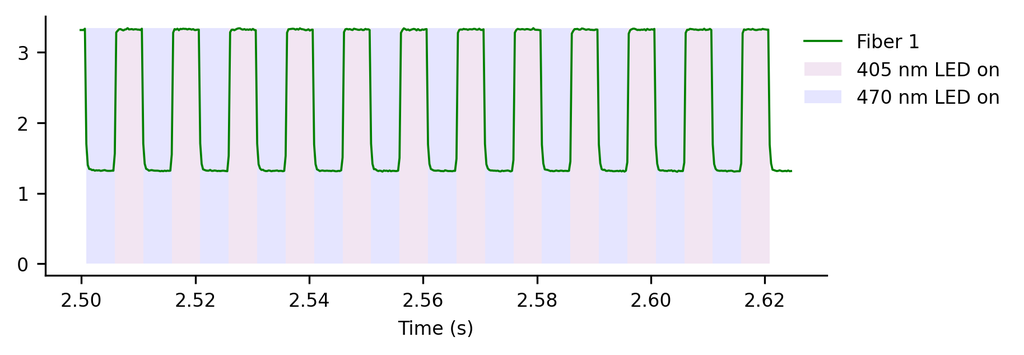

```python
import pandas as pd
from matplotlib import pyplot as plt

# Prepare data for plotting
data = fluorescence_picoscope.data[10000:10500, 0]
timestamps = fluorescence_picoscope.get_timestamps()[10000:10500]

fig, ax = plt.subplots(figsize=(6, 2), dpi=300)
line_handle, = ax.plot(timestamps, data, color="green", linewidth=0.9, label="Fiber 1")

ttl_0 = ttl_times[ttl_times["ttl_type"] == 0]
violet_illumination_times = ttl_0[(ttl_0["timestamp"] > 2.5) & (ttl_0["timestamp"] <= 2.62)]
violet_handles = []
for illumination_onset in violet_illumination_times["timestamp"]:
    fill_end = illumination_onset + 0.005
    violet_handle = ax.fill_between(timestamps, max(data), where=(timestamps >= illumination_onset) & (timestamps <= fill_end),
                                    color='purple', edgecolor='none', alpha=0.1, label="405 nm LED on")
    violet_handles.append(violet_handle)

ttl_1 = ttl_times[ttl_times["ttl_type"] == 1]
blue_illumination_times = ttl_1[(ttl_1["timestamp"] > 2.5) & (ttl_1["timestamp"] <= 2.62)]
blue_handles = []
for illumination_onset in blue_illumination_times["timestamp"]:
    fill_end = illumination_onset + 0.005
    blue_handle = ax.fill_between(timestamps, max(data), where=(timestamps >= illumination_onset) & (timestamps <= fill_end),
                                  color='blue', edgecolor='none', alpha=0.1, label="470 nm LED on")
    blue_handles.append(blue_handle)

# Hide top and right spines
ax.spines['top'].set_visible(False)
ax.spines['right'].set_visible(False)

# Create the legend with the appropriate handles
handles = [line_handle, violet_handles[0], blue_handles[0]]
labels = ["Fiber 1", "405 nm LED on", "470 nm LED on"]
ax.legend(handles, labels, frameon=False, bbox_to_anchor=(.95, 1), loc='upper left', prop={'size': 8})

ax.tick_params(axis='y', labelsize=8)
plt.xlabel('Time (s)', fontsize=8)
plt.tick_params(axis='x', labelsize=8)
plt.show()
```

## Fiber photometry traces

The fluorescence signals from the Picoscope were separated due to 405 vs 470 nm illumination (405 nm is GCaMP's isosbestic point and thus serves as a movement control) and were re-binned from 4000 Hz to 100 Hz.

The fluorescence traces are added to `nwbfile.acquisition` and are stored in a `FiberPhotometryResponseSeries` object using [`ndx-fiber-photometry`](https://github.com/catalystneuro/ndx-fiber-photometry). The fluorescence data during 470 nm excitation can be accessed as `nwbfile.acquisition["FiberPhotometryResponseSeries"]`. The control signal can be accessed as `nwbfile.acquisition["FiberPhotometryResponseSeriesIsosbestic"]`.

```python
fiber_photometry_response_series = nwbfile.acquisition["FiberPhotometryResponseSeries"]
fiber_photometry_response_series
```

FiberPhotometryResponseSeries

starting_time: 0.0

rate: 100.0

resolution: -1.0

comments: no comments

description: Raw green fluorescence collected during 470 nm illumination re-binned to 100 Hz and acquired with one or two optical fibers.

conversion: 1.0

offset: 0.0

unit: n.a.

**data**

HDF5 dataset

| Data type | float64 |
| --- | --- |
| Shape | (169024, 2) |
| Array size | 2.58 MiB |
| Chunk shape | (169024, 2) |
| Compression | gzip |
| Compression opts | 4 |
| Uncompressed size (bytes) | 2704384 |
| Compressed size (bytes) | 1137393 |
| Compression ratio | 2.377704100517587 |

starting_time_unit: seconds

**fiber_photometry_table_region (DynamicTableRegion)**

description: source fibers

**table (FiberPhotometryTable)**

description: Contains the metadata for the fiber photometry experiment.

**columns**

**location**

Location of fiber.

**indicator**

Link to the indicator object.

**optical_fiber**

Link to the optical fiber device.

**excitation_source**

Link to the excitation source device.

**photodetector**

Link to the photodetector device.

**dichroic_mirror**

Link to the dichroic mirror device.

**fiber_depth_in_mm**

The depth of the optical fiber in the unit of millimeters.

**baseline_fluorescence**

The baseline fluorescence value for each fiber.

**normalized_fluorescence**

The normalized fluorescence value for each fiber.

**recording_target_type**

Defines whether recordings are made in axons vs cell bodies.

**signal_to_noise_ratio**

The signal to noise ratio for each fiber.

**cross_correlation_with_acceleration**

The cross-correlation between ΔF/F and acceleration.

**coordinates**

Fiber placement in stereotactic coordinates (AP, ML, DV) mm relative to Bregma.

**emission_filter**

Link to the emission filter device.

**excitation_filter**

Link to the excitation filter device.

**table**

| id | location | indicator | optical_fiber | excitation_source | photodetector | dichroic_mirror | fiber_depth_in_mm | baseline_fluorescence | normalized_fluorescence | recording_target_type | signal_to_noise_ratio | cross_correlation_with_acceleration | coordinates | emission_filter | excitation_filter |
| --- | --- | --- | --- | --- | --- | --- | --- | --- | --- | --- | --- | --- | --- | --- | --- |
| 0 | SNc | GCaMP6f abc.Indicator at 0x139697612880736\nFields:\n injection_coordinates_in_mm: [-3.25 1.55 -3.8 ]\n injection_location: SNc\n label: AAV-GCaMP6f\n | Fiber1 abc.OpticalFiber at 0x139697608624176\nFields:\n core_diameter_in_um: 200.0\n description: The optical fiber used to record the GCaMP fluorescence from the SNc brain region.\n manufacturer: Dor… | ExcitationSource470 abc.ExcitationSource at 0x139697608510672\nFields:\n description: Blue excitation light (470 nm LED, Thorlabs, M70F3) and violet excitation light (for the isosbestic control)\nwere… | PhotodetectorPMT abc.Photodetector at 0x139697608624512\nFields:\n description: Hamamatsu GaAsP photomultiplier tube (signal amplified using Stanford Research Systems SR570 preamplifier).\n detected_w… | DichroicMirror abc.DichroicMirror at 0x139697608623168\nFields:\n cut_on_wavelength_in_nm: 505.0\n description: The dichroic mirror used to separate green fluorescence from the excitation light.\n man… | 3.6 | 1.041767 | 0.686421 | cell bodies in SNc | 18.898114 | 0.067393 | [nan, nan, nan] | EmissionFilter abc.BandOpticalFilter at 0x139697608623504\nFields:\n bandwidth_in_nm: 50.0\n center_wavelength_in_nm: 540.0\n description: The band-pass filter used to further filter the green fluores… | OpticalFilter470 abc.BandOpticalFilter at 0x139697608511632\nFields:\n bandwidth_in_nm: 30.0\n center_wavelength_in_nm: 472.0\n description: The band-pass filter used to isolate the 470 nm excitation … |
| 1 | TS | GCaMP6f abc.Indicator at 0x139697612880736\nFields:\n injection_coordinates_in_mm: [-3.25 1.55 -3.8 ]\n injection_location: SNc\n label: AAV-GCaMP6f\n | Fiber2 abc.OpticalFiber at 0x139697608510992\nFields:\n core_diameter_in_um: 200.0\n description: The second optical fiber used to record the GCaMP fluorescence from the TS brain region.\n manufacture… | ExcitationSource470 abc.ExcitationSource at 0x139697608510672\nFields:\n description: Blue excitation light (470 nm LED, Thorlabs, M70F3) and violet excitation light (for the isosbestic control)\nwere… | PhotodetectorPMT abc.Photodetector at 0x139697608624512\nFields:\n description: Hamamatsu GaAsP photomultiplier tube (signal amplified using Stanford Research Systems SR570 preamplifier).\n detected_w… | DichroicMirror abc.DichroicMirror at 0x139697608623168\nFields:\n cut_on_wavelength_in_nm: 505.0\n description: The dichroic mirror used to separate green fluorescence from the excitation light.\n man… | 1.0 | 1.050157 | 0.053596 | axons in striatum | 0.000000 | 0.014802 | [3.0748749730962577, -0.58, 2.1599445426572172] | EmissionFilter abc.BandOpticalFilter at 0x139697608623504\nFields:\n bandwidth_in_nm: 50.0\n center_wavelength_in_nm: 540.0\n description: The band-pass filter used to further filter the green fluores… | OpticalFilter470 abc.BandOpticalFilter at 0x139697608511632\nFields:\n bandwidth_in_nm: 30.0\n center_wavelength_in_nm: 472.0\n description: The band-pass filter used to isolate the 470 nm excitation … |
| 2 | SNc | GCaMP6f abc.Indicator at 0x139697612880736\nFields:\n injection_coordinates_in_mm: [-3.25 1.55 -3.8 ]\n injection_location: SNc\n label: AAV-GCaMP6f\n | Fiber1 abc.OpticalFiber at 0x139697608624176\nFields:\n core_diameter_in_um: 200.0\n description: The optical fiber used to record the GCaMP fluorescence from the SNc brain region.\n manufacturer: Dor… | ExcitationSource405 abc.ExcitationSource at 0x139697608623840\nFields:\n description: Violet LED (405 nm, Thorlabs, M405FP1) for the isosbestic control.\n excitation_wavelength_in_nm: 405.0\n illumina… | PhotodetectorPMT abc.Photodetector at 0x139697608624512\nFields:\n description: Hamamatsu GaAsP photomultiplier tube (signal amplified using Stanford Research Systems SR570 preamplifier).\n detected_w… | DichroicMirror abc.DichroicMirror at 0x139697608623168\nFields:\n cut_on_wavelength_in_nm: 505.0\n description: The dichroic mirror used to separate green fluorescence from the excitation light.\n man… | 3.6 | 1.041767 | 0.686421 | cell bodies in SNc | 18.898114 | 0.067393 | [nan, nan, nan] | EmissionFilter abc.BandOpticalFilter at 0x139697608623504\nFields:\n bandwidth_in_nm: 50.0\n center_wavelength_in_nm: 540.0\n description: The band-pass filter used to further filter the green fluores… | OpticalFilter405 abc.BandOpticalFilter at 0x139697608511312\nFields:\n bandwidth_in_nm: 15.0\n center_wavelength_in_nm: 406.0\n description: The band-pass filter used to isolate the 405 nm excitation … |
| 3 | TS | GCaMP6f abc.Indicator at 0x139697612880736\nFields:\n injection_coordinates_in_mm: [-3.25 1.55 -3.8 ]\n injection_location: SNc\n label: AAV-GCaMP6f\n | Fiber2 abc.OpticalFiber at 0x139697608510992\nFields:\n core_diameter_in_um: 200.0\n description: The second optical fiber used to record the GCaMP fluorescence from the TS brain region.\n manufacture… | ExcitationSource405 abc.ExcitationSource at 0x139697608623840\nFields:\n description: Violet LED (405 nm, Thorlabs, M405FP1) for the isosbestic control.\n excitation_wavelength_in_nm: 405.0\n illumina… | PhotodetectorPMT abc.Photodetector at 0x139697608624512\nFields:\n description: Hamamatsu GaAsP photomultiplier tube (signal amplified using Stanford Research Systems SR570 preamplifier).\n detected_w… | DichroicMirror abc.DichroicMirror at 0x139697608623168\nFields:\n cut_on_wavelength_in_nm: 505.0\n description: The dichroic mirror used to separate green fluorescence from the excitation light.\n man… | 1.0 | 1.050157 | 0.053596 | axons in striatum | 0.000000 | 0.014802 | [3.0748749730962577, -0.58, 2.1599445426572172] | EmissionFilter abc.BandOpticalFilter at 0x139697608623504\nFields:\n bandwidth_in_nm: 50.0\n center_wavelength_in_nm: 540.0\n description: The band-pass filter used to further filter the green fluores… | OpticalFilter405 abc.BandOpticalFilter at 0x139697608511312\nFields:\n bandwidth_in_nm: 15.0\n center_wavelength_in_nm: 406.0\n description: The band-pass filter used to isolate the 405 nm excitation … |

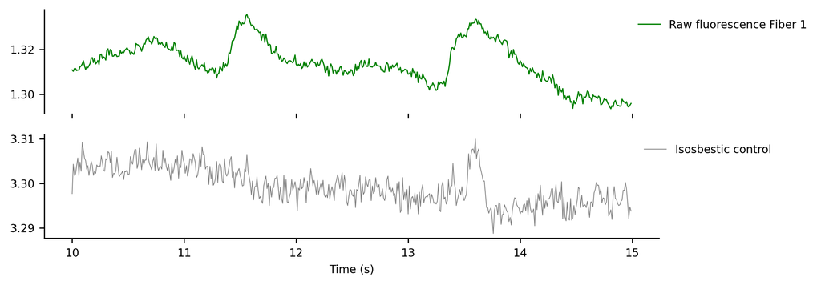

```python
import pandas as pd
from matplotlib import pyplot as plt

# Prepare data for plotting
data = fiber_photometry_response_series.data[1000:1500, 0]
timestamps = fiber_photometry_response_series.get_timestamps()[1000:1500]

control_signal = nwbfile.acquisition["FiberPhotometryResponseSeriesIsosbestic"]
control_data = control_signal.data[1000:1500, 0]

fig, ax = plt.subplots(nrows=2, ncols=1, figsize=(8, 3), dpi=300, sharex=True)

# Plot data
ax[0].plot(timestamps, data, color="green", linewidth=0.8, label='Data')

# Plot control data with offset
ax[1].plot(timestamps, control_data, color="grey", linewidth=0.5, label='Control Data (shifted)')

ax[0].spines['top'].set_visible(False)
ax[0].spines['right'].set_visible(False)
ax[0].spines['bottom'].set_visible(False)
ax[1].spines['top'].set_visible(False)
ax[1].spines['right'].set_visible(False)

ax[0].legend(["Raw fluorescence Fiber 1"], frameon=False, bbox_to_anchor=(.95, 1), loc='upper left', prop={'size': 8})
ax[1].legend(["Isosbestic control"], frameon=False, bbox_to_anchor=(.96, 1), loc='upper left', prop={'size': 8})
ax[1].tick_params(axis='y', labelsize=8)
ax[0].tick_params(axis='y', labelsize=8)


plt.xlabel('Time (s)', fontsize=8)
plt.tick_params(axis='x', labelsize=8)
plt.show()
```

## Fiber photometry metadata

The fiber photometry metadata includes the type of indicator(s), optical fiber(s), excitation source(s), photodector(s), dichroic mirror(s), and optical filter(s) that were used to construct a single fluorescence signal.

The metadata is stored in a `FiberPhotometryTable` object using [`ndx-fiber-photometry`](https://github.com/catalystneuro/ndx-fiber-photometry) and is added to `nwbfile.lab_meta_data`. It can be accessed as `nwbfile.lab_meta_data["FiberPhotometry"].fiber_photometry_table`.

```python
nwbfile.lab_meta_data["FiberPhotometry"].fiber_photometry_table[:]
```

| id | location | indicator | optical_fiber | excitation_source | photodetector | dichroic_mirror | fiber_depth_in_mm | baseline_fluorescence | normalized_fluorescence | recording_target_type | signal_to_noise_ratio | cross_correlation_with_acceleration | coordinates | emission_filter | excitation_filter |
| --- | --- | --- | --- | --- | --- | --- | --- | --- | --- | --- | --- | --- | --- | --- | --- |
| 0 | SNc | GCaMP6f abc.Indicator at 0x139697612880736\nFi... | Fiber1 abc.OpticalFiber at 0x139697608624176\n... | ExcitationSource470 abc.ExcitationSource at 0x... | PhotodetectorPMT abc.Photodetector at 0x139697... | DichroicMirror abc.DichroicMirror at 0x1396976... | 3.6 | 1.041767 | 0.686421 | cell bodies in SNc | 18.898114 | 0.067393 | [nan, nan, nan] | EmissionFilter abc.BandOpticalFilter at 0x1396... | OpticalFilter470 abc.BandOpticalFilter at 0x13... |
| 1 | TS | GCaMP6f abc.Indicator at 0x139697612880736\nFi... | Fiber2 abc.OpticalFiber at 0x139697608510992\n... | ExcitationSource470 abc.ExcitationSource at 0x... | PhotodetectorPMT abc.Photodetector at 0x139697... | DichroicMirror abc.DichroicMirror at 0x1396976... | 1.0 | 1.050157 | 0.053596 | axons in striatum | 0.000000 | 0.014802 | [3.0748749730962577, -0.58, 2.1599445426572172] | EmissionFilter abc.BandOpticalFilter at 0x1396... | OpticalFilter470 abc.BandOpticalFilter at 0x13... |
| 2 | SNc | GCaMP6f abc.Indicator at 0x139697612880736\nFi... | Fiber1 abc.OpticalFiber at 0x139697608624176\n... | ExcitationSource405 abc.ExcitationSource at 0x... | PhotodetectorPMT abc.Photodetector at 0x139697... | DichroicMirror abc.DichroicMirror at 0x1396976... | 3.6 | 1.041767 | 0.686421 | cell bodies in SNc | 18.898114 | 0.067393 | [nan, nan, nan] | EmissionFilter abc.BandOpticalFilter at 0x1396... | OpticalFilter405 abc.BandOpticalFilter at 0x13... |
| 3 | TS | GCaMP6f abc.Indicator at 0x139697612880736\nFi... | Fiber2 abc.OpticalFiber at 0x139697608510992\n... | ExcitationSource405 abc.ExcitationSource at 0x... | PhotodetectorPMT abc.Photodetector at 0x139697... | DichroicMirror abc.DichroicMirror at 0x1396976... | 1.0 | 1.050157 | 0.053596 | axons in striatum | 0.000000 | 0.014802 | [3.0748749730962577, -0.58, 2.1599445426572172] | EmissionFilter abc.BandOpticalFilter at 0x1396... | OpticalFilter405 abc.BandOpticalFilter at 0x13... |

The `fiber_photometry_table_region` attribute in the `FiberPhotometryResponseSeries` object references row(s) of this table:

```python
fiber_photometry_table_region = nwbfile.acquisition["FiberPhotometryResponseSeries"].fiber_photometry_table_region[:]
fiber_photometry_table_region
```

| id | location | indicator | optical_fiber | excitation_source | photodetector | dichroic_mirror | fiber_depth_in_mm | baseline_fluorescence | normalized_fluorescence | recording_target_type | signal_to_noise_ratio | cross_correlation_with_acceleration | coordinates | emission_filter | excitation_filter |
| --- | --- | --- | --- | --- | --- | --- | --- | --- | --- | --- | --- | --- | --- | --- | --- |
| 0 | SNc | GCaMP6f abc.Indicator at 0x139697612880736\nFi... | Fiber1 abc.OpticalFiber at 0x139697608624176\n... | ExcitationSource470 abc.ExcitationSource at 0x... | PhotodetectorPMT abc.Photodetector at 0x139697... | DichroicMirror abc.DichroicMirror at 0x1396976... | 3.6 | 1.041767 | 0.686421 | cell bodies in SNc | 18.898114 | 0.067393 | [nan, nan, nan] | EmissionFilter abc.BandOpticalFilter at 0x1396... | OpticalFilter470 abc.BandOpticalFilter at 0x13... |
| 1 | TS | GCaMP6f abc.Indicator at 0x139697612880736\nFi... | Fiber2 abc.OpticalFiber at 0x139697608510992\n... | ExcitationSource470 abc.ExcitationSource at 0x... | PhotodetectorPMT abc.Photodetector at 0x139697... | DichroicMirror abc.DichroicMirror at 0x1396976... | 1.0 | 1.050157 | 0.053596 | axons in striatum | 0.000000 | 0.014802 | [3.0748749730962577, -0.58, 2.1599445426572172] | EmissionFilter abc.BandOpticalFilter at 0x1396... | OpticalFilter470 abc.BandOpticalFilter at 0x13... |

The metadata on the optical fiber used to record the GCaMP fluorescence is added to `nwbfile.devices` and can be accessed as `nwbfile.devices["Fiber1"]` or can be accessed from the referenced optical fiber in the `fiber_photometry_table_region` of the `FiberPhotometryResponseSeries`.

```python
fiber_photometry_table_region["optical_fiber"][0]
```

Fiber1 (OpticalFiber)

description: The optical fiber used to record the GCaMP fluorescence from the SNc brain region.

manufacturer: Doric

model: MFP_200/230/900-0.57_1.5m_FC-FLT_LAF

numerical_aperture: 0.57

core_diameter_in_um: 200.0

```python
fiber_photometry_table_region["indicator"][0]
```

GCaMP6f (Indicator)

label: AAV-GCaMP6f

injection_location: SNc

**injection_coordinates_in_mm**

NumPy array

| Data type | float64 |
| --- | --- |
| Shape | (3,) |
| Array size | 24.00 bytes |

[-3.25 1.55 -3.8 ]

```python
fiber_photometry_table_region["excitation_source"][0]
```

ExcitationSource470 (ExcitationSource)

description: Blue excitation light (470 nm LED, Thorlabs, M70F3) and violet excitation light (for the isosbestic control) were coupled into the optic fiber such that a power of 0.75 mW was delivered to the fiber tip. Then, 470 nm and 405 nm excitation were alternated at 100 Hz using a waveform generator, each filtered with a corresponding filter.

manufacturer: Thorlabs

model: M70F3

illumination_type: LED

excitation_wavelength_in_nm: 470.0

```python
fiber_photometry_table_region["photodetector"][0]
```

PhotodetectorPMT (Photodetector)

description: Hamamatsu GaAsP photomultiplier tube (signal amplified using Stanford Research Systems SR570 preamplifier).

manufacturer: Hamamatsu Photonics

model: H10770PA-40

detector_type: PMT

detected_wavelength_in_nm: 520.0

```python
fiber_photometry_table_region["dichroic_mirror"][0]
```

DichroicMirror

description: The dichroic mirror used to separate green fluorescence from the excitation light.

manufacturer: Chroma Tech Corp

cut_on_wavelength_in_nm: 505.0

**transmission_band_in_nm**

NumPy array

| Data type | float64 |
| --- | --- |
| Shape | (2,) |
| Array size | 16.00 bytes |

[505. 750.]

model: T505lpxr

```python
fiber_photometry_table_region["emission_filter"][0]
```

EmissionFilter (BandOpticalFilter)

description: The band-pass filter used to further filter the green fluorescence after it was separated from the excitation light by a dichroic mirror.

manufacturer: Semrock

center_wavelength_in_nm: 540.0

bandwidth_in_nm: 50.0

filter_type: Bandpass

model: FF01-540/50-25

```python
fiber_photometry_table_region["excitation_filter"][0]
```

OpticalFilter470 (BandOpticalFilter)

description: The band-pass filter used to isolate the 470 nm excitation light.

manufacturer: Semrock

center_wavelength_in_nm: 472.0

bandwidth_in_nm: 30.0

filter_type: Bandpass

model: FF02-472/30-25

# Access processed fiber photometry data

This section demonstrates how to access the processed fiber photometry data in the NWBfile.

The processed fiber photometry data is stored in "processing/ophys" which can be accessed as `nwbfile.processing["ophys"]`. Within this processing module we can access the ∆F/F traces as `nwbfile.processing["ophys"]["DfOverFFiberPhotometryResponseSeries"]`.

```python
nwbfile.processing["ophys"]
```

ophys (ProcessingModule)

description: Processed fiber photometry data.

**DfOverFFiberPhotometryResponseSeries (FiberPhotometryResponseSeries)**

starting_time: 13.91

rate: 100.0

resolution: -1.0

comments: no comments

description: DF/F calculated from green fluorescence collected during 470 nm illumination re-binned to 100 Hz and acquired with one or two optical fibers.

conversion: 1.0

offset: 0.0

unit: n.a.

**data**

HDF5 dataset

| Data type | float64 |
| --- | --- |
| Shape | (167634, 2) |
| Array size | 2.56 MiB |
| Chunk shape | (167634, 2) |
| Compression | gzip |
| Compression opts | 4 |
| Uncompressed size (bytes) | 2682144 |
| Compressed size (bytes) | 2436481 |
| Compression ratio | 1.1008269713574619 |

starting_time_unit: seconds

**fiber_photometry_table_region (DynamicTableRegion)**

description: source fibers

**table (FiberPhotometryTable)**

description: Contains the metadata for the fiber photometry experiment.

**columns**

**location**

Location of fiber.

**indicator**

Link to the indicator object.

**optical_fiber**

Link to the optical fiber device.

**excitation_source**

Link to the excitation source device.

**photodetector**

Link to the photodetector device.

**dichroic_mirror**

Link to the dichroic mirror device.

**fiber_depth_in_mm**

The depth of the optical fiber in the unit of millimeters.

**baseline_fluorescence**

The baseline fluorescence value for each fiber.

**normalized_fluorescence**

The normalized fluorescence value for each fiber.

**recording_target_type**

Defines whether recordings are made in axons vs cell bodies.

**signal_to_noise_ratio**

The signal to noise ratio for each fiber.

**cross_correlation_with_acceleration**

The cross-correlation between ΔF/F and acceleration.

**coordinates**

Fiber placement in stereotactic coordinates (AP, ML, DV) mm relative to Bregma.

**emission_filter**

Link to the emission filter device.

**excitation_filter**

Link to the excitation filter device.

**table**

| id | location | indicator | optical_fiber | excitation_source | photodetector | dichroic_mirror | fiber_depth_in_mm | baseline_fluorescence | normalized_fluorescence | recording_target_type | signal_to_noise_ratio | cross_correlation_with_acceleration | coordinates | emission_filter | excitation_filter |
| --- | --- | --- | --- | --- | --- | --- | --- | --- | --- | --- | --- | --- | --- | --- | --- |
| 0 | SNc | GCaMP6f abc.Indicator at 0x139697612880736\nFields:\n injection_coordinates_in_mm: [-3.25 1.55 -3.8 ]\n injection_location: SNc\n label: AAV-GCaMP6f\n | Fiber1 abc.OpticalFiber at 0x139697608624176\nFields:\n core_diameter_in_um: 200.0\n description: The optical fiber used to record the GCaMP fluorescence from the SNc brain region.\n manufacturer: Dor… | ExcitationSource470 abc.ExcitationSource at 0x139697608510672\nFields:\n description: Blue excitation light (470 nm LED, Thorlabs, M70F3) and violet excitation light (for the isosbestic control)\nwere… | PhotodetectorPMT abc.Photodetector at 0x139697608624512\nFields:\n description: Hamamatsu GaAsP photomultiplier tube (signal amplified using Stanford Research Systems SR570 preamplifier).\n detected_w… | DichroicMirror abc.DichroicMirror at 0x139697608623168\nFields:\n cut_on_wavelength_in_nm: 505.0\n description: The dichroic mirror used to separate green fluorescence from the excitation light.\n man… | 3.6 | 1.041767 | 0.686421 | cell bodies in SNc | 18.898114 | 0.067393 | [nan, nan, nan] | EmissionFilter abc.BandOpticalFilter at 0x139697608623504\nFields:\n bandwidth_in_nm: 50.0\n center_wavelength_in_nm: 540.0\n description: The band-pass filter used to further filter the green fluores… | OpticalFilter470 abc.BandOpticalFilter at 0x139697608511632\nFields:\n bandwidth_in_nm: 30.0\n center_wavelength_in_nm: 472.0\n description: The band-pass filter used to isolate the 470 nm excitation … |
| 1 | TS | GCaMP6f abc.Indicator at 0x139697612880736\nFields:\n injection_coordinates_in_mm: [-3.25 1.55 -3.8 ]\n injection_location: SNc\n label: AAV-GCaMP6f\n | Fiber2 abc.OpticalFiber at 0x139697608510992\nFields:\n core_diameter_in_um: 200.0\n description: The second optical fiber used to record the GCaMP fluorescence from the TS brain region.\n manufacture… | ExcitationSource470 abc.ExcitationSource at 0x139697608510672\nFields:\n description: Blue excitation light (470 nm LED, Thorlabs, M70F3) and violet excitation light (for the isosbestic control)\nwere… | PhotodetectorPMT abc.Photodetector at 0x139697608624512\nFields:\n description: Hamamatsu GaAsP photomultiplier tube (signal amplified using Stanford Research Systems SR570 preamplifier).\n detected_w… | DichroicMirror abc.DichroicMirror at 0x139697608623168\nFields:\n cut_on_wavelength_in_nm: 505.0\n description: The dichroic mirror used to separate green fluorescence from the excitation light.\n man… | 1.0 | 1.050157 | 0.053596 | axons in striatum | 0.000000 | 0.014802 | [3.0748749730962577, -0.58, 2.1599445426572172] | EmissionFilter abc.BandOpticalFilter at 0x139697608623504\nFields:\n bandwidth_in_nm: 50.0\n center_wavelength_in_nm: 540.0\n description: The band-pass filter used to further filter the green fluores… | OpticalFilter470 abc.BandOpticalFilter at 0x139697608511632\nFields:\n bandwidth_in_nm: 30.0\n center_wavelength_in_nm: 472.0\n description: The band-pass filter used to isolate the 470 nm excitation … |
| 2 | SNc | GCaMP6f abc.Indicator at 0x139697612880736\nFields:\n injection_coordinates_in_mm: [-3.25 1.55 -3.8 ]\n injection_location: SNc\n label: AAV-GCaMP6f\n | Fiber1 abc.OpticalFiber at 0x139697608624176\nFields:\n core_diameter_in_um: 200.0\n description: The optical fiber used to record the GCaMP fluorescence from the SNc brain region.\n manufacturer: Dor… | ExcitationSource405 abc.ExcitationSource at 0x139697608623840\nFields:\n description: Violet LED (405 nm, Thorlabs, M405FP1) for the isosbestic control.\n excitation_wavelength_in_nm: 405.0\n illumina… | PhotodetectorPMT abc.Photodetector at 0x139697608624512\nFields:\n description: Hamamatsu GaAsP photomultiplier tube (signal amplified using Stanford Research Systems SR570 preamplifier).\n detected_w… | DichroicMirror abc.DichroicMirror at 0x139697608623168\nFields:\n cut_on_wavelength_in_nm: 505.0\n description: The dichroic mirror used to separate green fluorescence from the excitation light.\n man… | 3.6 | 1.041767 | 0.686421 | cell bodies in SNc | 18.898114 | 0.067393 | [nan, nan, nan] | EmissionFilter abc.BandOpticalFilter at 0x139697608623504\nFields:\n bandwidth_in_nm: 50.0\n center_wavelength_in_nm: 540.0\n description: The band-pass filter used to further filter the green fluores… | OpticalFilter405 abc.BandOpticalFilter at 0x139697608511312\nFields:\n bandwidth_in_nm: 15.0\n center_wavelength_in_nm: 406.0\n description: The band-pass filter used to isolate the 405 nm excitation … |
| 3 | TS | GCaMP6f abc.Indicator at 0x139697612880736\nFields:\n injection_coordinates_in_mm: [-3.25 1.55 -3.8 ]\n injection_location: SNc\n label: AAV-GCaMP6f\n | Fiber2 abc.OpticalFiber at 0x139697608510992\nFields:\n core_diameter_in_um: 200.0\n description: The second optical fiber used to record the GCaMP fluorescence from the TS brain region.\n manufacture… | ExcitationSource405 abc.ExcitationSource at 0x139697608623840\nFields:\n description: Violet LED (405 nm, Thorlabs, M405FP1) for the isosbestic control.\n excitation_wavelength_in_nm: 405.0\n illumina… | PhotodetectorPMT abc.Photodetector at 0x139697608624512\nFields:\n description: Hamamatsu GaAsP photomultiplier tube (signal amplified using Stanford Research Systems SR570 preamplifier).\n detected_w… | DichroicMirror abc.DichroicMirror at 0x139697608623168\nFields:\n cut_on_wavelength_in_nm: 505.0\n description: The dichroic mirror used to separate green fluorescence from the excitation light.\n man… | 1.0 | 1.050157 | 0.053596 | axons in striatum | 0.000000 | 0.014802 | [3.0748749730962577, -0.58, 2.1599445426572172] | EmissionFilter abc.BandOpticalFilter at 0x139697608623504\nFields:\n bandwidth_in_nm: 50.0\n center_wavelength_in_nm: 540.0\n description: The band-pass filter used to further filter the green fluores… | OpticalFilter405 abc.BandOpticalFilter at 0x139697608511312\nFields:\n bandwidth_in_nm: 15.0\n center_wavelength_in_nm: 406.0\n description: The band-pass filter used to isolate the 405 nm excitation … |

**DfOverFFiberPhotometryResponseSeriesIsosbestic (FiberPhotometryResponseSeries)**

starting_time: 13.91

rate: 100.0

resolution: -1.0

comments: no comments

description: DF/F calculated from green fluorescence collected at its isosbestic wavelength (405 nm) re-binned to 100 Hz and acquired with one or two optical fibers.

conversion: 1.0

offset: 0.0

unit: n.a.

**data**

HDF5 dataset

| Data type | float64 |
| --- | --- |
| Shape | (167634, 2) |
| Array size | 2.56 MiB |
| Chunk shape | (167634, 2) |
| Compression | gzip |
| Compression opts | 4 |
| Uncompressed size (bytes) | 2682144 |
| Compressed size (bytes) | 2544179 |
| Compression ratio | 1.0542277096069106 |

starting_time_unit: seconds

**fiber_photometry_table_region (DynamicTableRegion)**

description: source fibers

**table (FiberPhotometryTable)**

description: Contains the metadata for the fiber photometry experiment.

**columns**

**location**

Location of fiber.

**indicator**

Link to the indicator object.

**optical_fiber**

Link to the optical fiber device.

**excitation_source**

Link to the excitation source device.

**photodetector**

Link to the photodetector device.

**dichroic_mirror**

Link to the dichroic mirror device.

**fiber_depth_in_mm**

The depth of the optical fiber in the unit of millimeters.

**baseline_fluorescence**

The baseline fluorescence value for each fiber.

**normalized_fluorescence**

The normalized fluorescence value for each fiber.

**recording_target_type**

Defines whether recordings are made in axons vs cell bodies.

**signal_to_noise_ratio**

The signal to noise ratio for each fiber.

**cross_correlation_with_acceleration**

The cross-correlation between ΔF/F and acceleration.

**coordinates**

Fiber placement in stereotactic coordinates (AP, ML, DV) mm relative to Bregma.

**emission_filter**

Link to the emission filter device.

**excitation_filter**

Link to the excitation filter device.

**table**

| id | location | indicator | optical_fiber | excitation_source | photodetector | dichroic_mirror | fiber_depth_in_mm | baseline_fluorescence | normalized_fluorescence | recording_target_type | signal_to_noise_ratio | cross_correlation_with_acceleration | coordinates | emission_filter | excitation_filter |
| --- | --- | --- | --- | --- | --- | --- | --- | --- | --- | --- | --- | --- | --- | --- | --- |
| 0 | SNc | GCaMP6f abc.Indicator at 0x139697612880736\nFields:\n injection_coordinates_in_mm: [-3.25 1.55 -3.8 ]\n injection_location: SNc\n label: AAV-GCaMP6f\n | Fiber1 abc.OpticalFiber at 0x139697608624176\nFields:\n core_diameter_in_um: 200.0\n description: The optical fiber used to record the GCaMP fluorescence from the SNc brain region.\n manufacturer: Dor… | ExcitationSource470 abc.ExcitationSource at 0x139697608510672\nFields:\n description: Blue excitation light (470 nm LED, Thorlabs, M70F3) and violet excitation light (for the isosbestic control)\nwere… | PhotodetectorPMT abc.Photodetector at 0x139697608624512\nFields:\n description: Hamamatsu GaAsP photomultiplier tube (signal amplified using Stanford Research Systems SR570 preamplifier).\n detected_w… | DichroicMirror abc.DichroicMirror at 0x139697608623168\nFields:\n cut_on_wavelength_in_nm: 505.0\n description: The dichroic mirror used to separate green fluorescence from the excitation light.\n man… | 3.6 | 1.041767 | 0.686421 | cell bodies in SNc | 18.898114 | 0.067393 | [nan, nan, nan] | EmissionFilter abc.BandOpticalFilter at 0x139697608623504\nFields:\n bandwidth_in_nm: 50.0\n center_wavelength_in_nm: 540.0\n description: The band-pass filter used to further filter the green fluores… | OpticalFilter470 abc.BandOpticalFilter at 0x139697608511632\nFields:\n bandwidth_in_nm: 30.0\n center_wavelength_in_nm: 472.0\n description: The band-pass filter used to isolate the 470 nm excitation … |
| 1 | TS | GCaMP6f abc.Indicator at 0x139697612880736\nFields:\n injection_coordinates_in_mm: [-3.25 1.55 -3.8 ]\n injection_location: SNc\n label: AAV-GCaMP6f\n | Fiber2 abc.OpticalFiber at 0x139697608510992\nFields:\n core_diameter_in_um: 200.0\n description: The second optical fiber used to record the GCaMP fluorescence from the TS brain region.\n manufacture… | ExcitationSource470 abc.ExcitationSource at 0x139697608510672\nFields:\n description: Blue excitation light (470 nm LED, Thorlabs, M70F3) and violet excitation light (for the isosbestic control)\nwere… | PhotodetectorPMT abc.Photodetector at 0x139697608624512\nFields:\n description: Hamamatsu GaAsP photomultiplier tube (signal amplified using Stanford Research Systems SR570 preamplifier).\n detected_w… | DichroicMirror abc.DichroicMirror at 0x139697608623168\nFields:\n cut_on_wavelength_in_nm: 505.0\n description: The dichroic mirror used to separate green fluorescence from the excitation light.\n man… | 1.0 | 1.050157 | 0.053596 | axons in striatum | 0.000000 | 0.014802 | [3.0748749730962577, -0.58, 2.1599445426572172] | EmissionFilter abc.BandOpticalFilter at 0x139697608623504\nFields:\n bandwidth_in_nm: 50.0\n center_wavelength_in_nm: 540.0\n description: The band-pass filter used to further filter the green fluores… | OpticalFilter470 abc.BandOpticalFilter at 0x139697608511632\nFields:\n bandwidth_in_nm: 30.0\n center_wavelength_in_nm: 472.0\n description: The band-pass filter used to isolate the 470 nm excitation … |
| 2 | SNc | GCaMP6f abc.Indicator at 0x139697612880736\nFields:\n injection_coordinates_in_mm: [-3.25 1.55 -3.8 ]\n injection_location: SNc\n label: AAV-GCaMP6f\n | Fiber1 abc.OpticalFiber at 0x139697608624176\nFields:\n core_diameter_in_um: 200.0\n description: The optical fiber used to record the GCaMP fluorescence from the SNc brain region.\n manufacturer: Dor… | ExcitationSource405 abc.ExcitationSource at 0x139697608623840\nFields:\n description: Violet LED (405 nm, Thorlabs, M405FP1) for the isosbestic control.\n excitation_wavelength_in_nm: 405.0\n illumina… | PhotodetectorPMT abc.Photodetector at 0x139697608624512\nFields:\n description: Hamamatsu GaAsP photomultiplier tube (signal amplified using Stanford Research Systems SR570 preamplifier).\n detected_w… | DichroicMirror abc.DichroicMirror at 0x139697608623168\nFields:\n cut_on_wavelength_in_nm: 505.0\n description: The dichroic mirror used to separate green fluorescence from the excitation light.\n man… | 3.6 | 1.041767 | 0.686421 | cell bodies in SNc | 18.898114 | 0.067393 | [nan, nan, nan] | EmissionFilter abc.BandOpticalFilter at 0x139697608623504\nFields:\n bandwidth_in_nm: 50.0\n center_wavelength_in_nm: 540.0\n description: The band-pass filter used to further filter the green fluores… | OpticalFilter405 abc.BandOpticalFilter at 0x139697608511312\nFields:\n bandwidth_in_nm: 15.0\n center_wavelength_in_nm: 406.0\n description: The band-pass filter used to isolate the 405 nm excitation … |
| 3 | TS | GCaMP6f abc.Indicator at 0x139697612880736\nFields:\n injection_coordinates_in_mm: [-3.25 1.55 -3.8 ]\n injection_location: SNc\n label: AAV-GCaMP6f\n | Fiber2 abc.OpticalFiber at 0x139697608510992\nFields:\n core_diameter_in_um: 200.0\n description: The second optical fiber used to record the GCaMP fluorescence from the TS brain region.\n manufacture… | ExcitationSource405 abc.ExcitationSource at 0x139697608623840\nFields:\n description: Violet LED (405 nm, Thorlabs, M405FP1) for the isosbestic control.\n excitation_wavelength_in_nm: 405.0\n illumina… | PhotodetectorPMT abc.Photodetector at 0x139697608624512\nFields:\n description: Hamamatsu GaAsP photomultiplier tube (signal amplified using Stanford Research Systems SR570 preamplifier).\n detected_w… | DichroicMirror abc.DichroicMirror at 0x139697608623168\nFields:\n cut_on_wavelength_in_nm: 505.0\n description: The dichroic mirror used to separate green fluorescence from the excitation light.\n man… | 1.0 | 1.050157 | 0.053596 | axons in striatum | 0.000000 | 0.014802 | [3.0748749730962577, -0.58, 2.1599445426572172] | EmissionFilter abc.BandOpticalFilter at 0x139697608623504\nFields:\n bandwidth_in_nm: 50.0\n center_wavelength_in_nm: 540.0\n description: The band-pass filter used to further filter the green fluores… | OpticalFilter405 abc.BandOpticalFilter at 0x139697608511312\nFields:\n bandwidth_in_nm: 15.0\n center_wavelength_in_nm: 406.0\n description: The band-pass filter used to isolate the 405 nm excitation … |

```python
df_over_f_traces = nwbfile.processing["ophys"]["DfOverFFiberPhotometryResponseSeries"]
df_over_f_traces
```

DfOverFFiberPhotometryResponseSeries (FiberPhotometryResponseSeries)

starting_time: 13.91

rate: 100.0

resolution: -1.0

comments: no comments

description: DF/F calculated from green fluorescence collected during 470 nm illumination re-binned to 100 Hz and acquired with one or two optical fibers.

conversion: 1.0

offset: 0.0

unit: n.a.

**data**

HDF5 dataset

| Data type | float64 |
| --- | --- |
| Shape | (167634, 2) |
| Array size | 2.56 MiB |
| Chunk shape | (167634, 2) |
| Compression | gzip |
| Compression opts | 4 |
| Uncompressed size (bytes) | 2682144 |
| Compressed size (bytes) | 2436481 |
| Compression ratio | 1.1008269713574619 |

starting_time_unit: seconds

**fiber_photometry_table_region (DynamicTableRegion)**

description: source fibers

**table (FiberPhotometryTable)**

description: Contains the metadata for the fiber photometry experiment.

**columns**

**location**

Location of fiber.

**indicator**

Link to the indicator object.

**optical_fiber**

Link to the optical fiber device.

**excitation_source**

Link to the excitation source device.

**photodetector**

Link to the photodetector device.

**dichroic_mirror**

Link to the dichroic mirror device.

**fiber_depth_in_mm**

The depth of the optical fiber in the unit of millimeters.

**baseline_fluorescence**

The baseline fluorescence value for each fiber.

**normalized_fluorescence**

The normalized fluorescence value for each fiber.

**recording_target_type**

Defines whether recordings are made in axons vs cell bodies.

**signal_to_noise_ratio**

The signal to noise ratio for each fiber.

**cross_correlation_with_acceleration**

The cross-correlation between ΔF/F and acceleration.

**coordinates**

Fiber placement in stereotactic coordinates (AP, ML, DV) mm relative to Bregma.

**emission_filter**

Link to the emission filter device.

**excitation_filter**

Link to the excitation filter device.

**table**

| id | location | indicator | optical_fiber | excitation_source | photodetector | dichroic_mirror | fiber_depth_in_mm | baseline_fluorescence | normalized_fluorescence | recording_target_type | signal_to_noise_ratio | cross_correlation_with_acceleration | coordinates | emission_filter | excitation_filter |
| --- | --- | --- | --- | --- | --- | --- | --- | --- | --- | --- | --- | --- | --- | --- | --- |
| 0 | SNc | GCaMP6f abc.Indicator at 0x139697612880736\nFields:\n injection_coordinates_in_mm: [-3.25 1.55 -3.8 ]\n injection_location: SNc\n label: AAV-GCaMP6f\n | Fiber1 abc.OpticalFiber at 0x139697608624176\nFields:\n core_diameter_in_um: 200.0\n description: The optical fiber used to record the GCaMP fluorescence from the SNc brain region.\n manufacturer: Dor… | ExcitationSource470 abc.ExcitationSource at 0x139697608510672\nFields:\n description: Blue excitation light (470 nm LED, Thorlabs, M70F3) and violet excitation light (for the isosbestic control)\nwere… | PhotodetectorPMT abc.Photodetector at 0x139697608624512\nFields:\n description: Hamamatsu GaAsP photomultiplier tube (signal amplified using Stanford Research Systems SR570 preamplifier).\n detected_w… | DichroicMirror abc.DichroicMirror at 0x139697608623168\nFields:\n cut_on_wavelength_in_nm: 505.0\n description: The dichroic mirror used to separate green fluorescence from the excitation light.\n man… | 3.6 | 1.041767 | 0.686421 | cell bodies in SNc | 18.898114 | 0.067393 | [nan, nan, nan] | EmissionFilter abc.BandOpticalFilter at 0x139697608623504\nFields:\n bandwidth_in_nm: 50.0\n center_wavelength_in_nm: 540.0\n description: The band-pass filter used to further filter the green fluores… | OpticalFilter470 abc.BandOpticalFilter at 0x139697608511632\nFields:\n bandwidth_in_nm: 30.0\n center_wavelength_in_nm: 472.0\n description: The band-pass filter used to isolate the 470 nm excitation … |
| 1 | TS | GCaMP6f abc.Indicator at 0x139697612880736\nFields:\n injection_coordinates_in_mm: [-3.25 1.55 -3.8 ]\n injection_location: SNc\n label: AAV-GCaMP6f\n | Fiber2 abc.OpticalFiber at 0x139697608510992\nFields:\n core_diameter_in_um: 200.0\n description: The second optical fiber used to record the GCaMP fluorescence from the TS brain region.\n manufacture… | ExcitationSource470 abc.ExcitationSource at 0x139697608510672\nFields:\n description: Blue excitation light (470 nm LED, Thorlabs, M70F3) and violet excitation light (for the isosbestic control)\nwere… | PhotodetectorPMT abc.Photodetector at 0x139697608624512\nFields:\n description: Hamamatsu GaAsP photomultiplier tube (signal amplified using Stanford Research Systems SR570 preamplifier).\n detected_w… | DichroicMirror abc.DichroicMirror at 0x139697608623168\nFields:\n cut_on_wavelength_in_nm: 505.0\n description: The dichroic mirror used to separate green fluorescence from the excitation light.\n man… | 1.0 | 1.050157 | 0.053596 | axons in striatum | 0.000000 | 0.014802 | [3.0748749730962577, -0.58, 2.1599445426572172] | EmissionFilter abc.BandOpticalFilter at 0x139697608623504\nFields:\n bandwidth_in_nm: 50.0\n center_wavelength_in_nm: 540.0\n description: The band-pass filter used to further filter the green fluores… | OpticalFilter470 abc.BandOpticalFilter at 0x139697608511632\nFields:\n bandwidth_in_nm: 30.0\n center_wavelength_in_nm: 472.0\n description: The band-pass filter used to isolate the 470 nm excitation … |
| 2 | SNc | GCaMP6f abc.Indicator at 0x139697612880736\nFields:\n injection_coordinates_in_mm: [-3.25 1.55 -3.8 ]\n injection_location: SNc\n label: AAV-GCaMP6f\n | Fiber1 abc.OpticalFiber at 0x139697608624176\nFields:\n core_diameter_in_um: 200.0\n description: The optical fiber used to record the GCaMP fluorescence from the SNc brain region.\n manufacturer: Dor… | ExcitationSource405 abc.ExcitationSource at 0x139697608623840\nFields:\n description: Violet LED (405 nm, Thorlabs, M405FP1) for the isosbestic control.\n excitation_wavelength_in_nm: 405.0\n illumina… | PhotodetectorPMT abc.Photodetector at 0x139697608624512\nFields:\n description: Hamamatsu GaAsP photomultiplier tube (signal amplified using Stanford Research Systems SR570 preamplifier).\n detected_w… | DichroicMirror abc.DichroicMirror at 0x139697608623168\nFields:\n cut_on_wavelength_in_nm: 505.0\n description: The dichroic mirror used to separate green fluorescence from the excitation light.\n man… | 3.6 | 1.041767 | 0.686421 | cell bodies in SNc | 18.898114 | 0.067393 | [nan, nan, nan] | EmissionFilter abc.BandOpticalFilter at 0x139697608623504\nFields:\n bandwidth_in_nm: 50.0\n center_wavelength_in_nm: 540.0\n description: The band-pass filter used to further filter the green fluores… | OpticalFilter405 abc.BandOpticalFilter at 0x139697608511312\nFields:\n bandwidth_in_nm: 15.0\n center_wavelength_in_nm: 406.0\n description: The band-pass filter used to isolate the 405 nm excitation … |
| 3 | TS | GCaMP6f abc.Indicator at 0x139697612880736\nFields:\n injection_coordinates_in_mm: [-3.25 1.55 -3.8 ]\n injection_location: SNc\n label: AAV-GCaMP6f\n | Fiber2 abc.OpticalFiber at 0x139697608510992\nFields:\n core_diameter_in_um: 200.0\n description: The second optical fiber used to record the GCaMP fluorescence from the TS brain region.\n manufacture… | ExcitationSource405 abc.ExcitationSource at 0x139697608623840\nFields:\n description: Violet LED (405 nm, Thorlabs, M405FP1) for the isosbestic control.\n excitation_wavelength_in_nm: 405.0\n illumina… | PhotodetectorPMT abc.Photodetector at 0x139697608624512\nFields:\n description: Hamamatsu GaAsP photomultiplier tube (signal amplified using Stanford Research Systems SR570 preamplifier).\n detected_w… | DichroicMirror abc.DichroicMirror at 0x139697608623168\nFields:\n cut_on_wavelength_in_nm: 505.0\n description: The dichroic mirror used to separate green fluorescence from the excitation light.\n man… | 1.0 | 1.050157 | 0.053596 | axons in striatum | 0.000000 | 0.014802 | [3.0748749730962577, -0.58, 2.1599445426572172] | EmissionFilter abc.BandOpticalFilter at 0x139697608623504\nFields:\n bandwidth_in_nm: 50.0\n center_wavelength_in_nm: 540.0\n description: The band-pass filter used to further filter the green fluores… | OpticalFilter405 abc.BandOpticalFilter at 0x139697608511312\nFields:\n bandwidth_in_nm: 15.0\n center_wavelength_in_nm: 406.0\n description: The band-pass filter used to isolate the 405 nm excitation … |

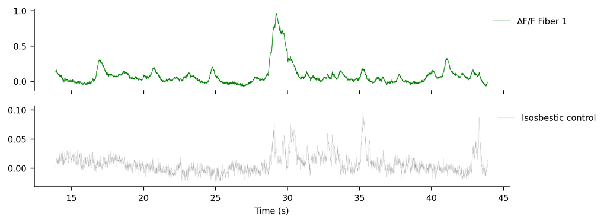

```python
import pandas as pd
from matplotlib import pyplot as plt

# Prepare data for plotting
data = df_over_f_traces.data[0:3000, 0]
timestamps = df_over_f_traces.get_timestamps()[0:3000]

control_signal = nwbfile.processing["ophys"]["DfOverFFiberPhotometryResponseSeriesIsosbestic"]
control_data = control_signal.data[0:3000, 0]

fig, ax = plt.subplots(nrows=2, ncols=1, figsize=(8, 3), dpi=300, sharex=True)

# Plot data
ax[0].plot(timestamps, data, color="green", linewidth=0.5)

# Plot control data with offset
ax[1].plot(timestamps, control_data, color="grey", linewidth=0.1)

ax[0].spines['top'].set_visible(False)
ax[0].spines['right'].set_visible(False)
ax[0].spines['bottom'].set_visible(False)
ax[1].spines['top'].set_visible(False)
ax[1].spines['right'].set_visible(False)

ax[0].legend(["∆F/F Fiber 1"], frameon=False, bbox_to_anchor=(.95, 1), loc='upper left', prop={'size': 8})
ax[1].legend(["Isosbestic control"], frameon=False, bbox_to_anchor=(.96, 1), loc='upper left', prop={'size': 8})
ax[1].tick_params(axis='y', labelsize=8)
ax[0].tick_params(axis='y', labelsize=8)


plt.xlabel('Time (s)', fontsize=8)
plt.tick_params(axis='x', labelsize=8)
plt.show()
```

# Access processed behavior

This section demonstrates how to access the processed behavior data in the NWBfile.

The processed behavior data (veloctity, acceleration) is stored in "processing/behavior" which can be accessed as `nwbfile.processing["behavior"]`. Within this processing module we can access the velocity from the rotary encoder as `nwbfile.processing["behavior"]["Velocity"]`.

```python
nwbfile.processing["behavior"]["Velocity"]
```

Velocity (TimeSeries)

starting_time: 13.91

rate: 100.0

resolution: -1.0

comments: no comments

description: The velocity from rotary encoder converted to m/s.

conversion: 1.0

offset: 0.0

unit: m/s

**data**

HDF5 dataset

| Data type | float64 |
| --- | --- |
| Shape | (167634,) |
| Array size | 1.28 MiB |
| Chunk shape | (167634,) |
| Compression | gzip |
| Compression opts | 4 |
| Uncompressed size (bytes) | 1341072 |
| Compressed size (bytes) | 1219633 |
| Compression ratio | 1.099570116584251 |

starting_time_unit: seconds

## Access derived events

### Wheel events

The derived events from the wheel (accelerations, decelerations) are also stored in an `EventsTable` object using [`ndx-events`](https://github.com/rly/ndx-events) and can be accessed as `nwbfile.processing["behavior"]["WheelEvents"]`. The id and the description of the events can be accessed as `nwbfile.processing["behavior"]["WheelEventTypes"]`.

```python
import pandas as pd

wheel_events = pd.merge(
    left=nwbfile.processing["behavior"]["WheelEvents"][:],
    right=nwbfile.processing["behavior"]["WheelEventTypes"][:],
    left_on="event_type",
    right_on="id",
)
wheel_events.head()
```

|  | timestamp | event_type | event_name | event_type_description |
| --- | --- | --- | --- | --- |
| 0 | 13.95 | 0 | Acceleration onset | The times of the Acceleration onset event. |
| 1 | 16.93 | 0 | Acceleration onset | The times of the Acceleration onset event. |
| 2 | 21.87 | 0 | Acceleration onset | The times of the Acceleration onset event. |
| 3 | 27.46 | 1 | Deceleration onset | The times of the Deceleration onset event. |
| 4 | 27.83 | 0 | Acceleration onset | The times of the Acceleration onset event. |

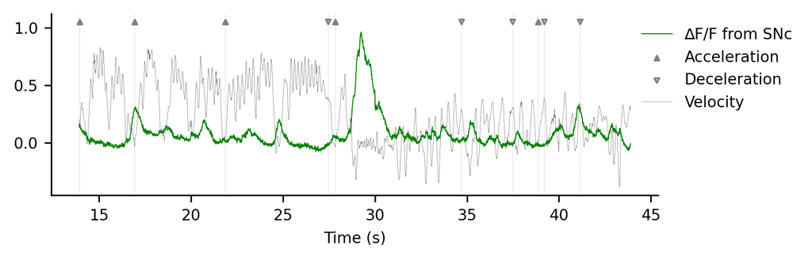

```python
import pandas as pd
from matplotlib import pyplot as plt

# Prepare data for plotting
data = df_over_f_traces.data[:3000, 0]
timestamps = df_over_f_traces.get_timestamps()[:3000]

velocity_data = nwbfile.processing["behavior"]["Velocity"].data[:3000]

# Add events during selected time
accelerations = wheel_events[wheel_events["event_type"] == 0]
accelerations = accelerations[accelerations["timestamp"] <= 45]["timestamp"]

decelerations = wheel_events[wheel_events["event_type"] == 1]
decelerations = decelerations[decelerations["timestamp"] <= 45]["timestamp"]

fig, ax = plt.subplots(nrows=1, ncols=1, figsize=(6, 2), dpi=300, sharex=True)

# Plot the main data
data_handle, = ax.plot(timestamps, data, color="green", linewidth=0.5, label="∆F/F from SNc")

# Add vertical lines for events
for time in accelerations:
    ax.axvline(time, color='grey', linewidth=0.1, linestyle="--")
for time in decelerations:
    ax.axvline(time, color='grey', linewidth=0.1, linestyle="--")

# Add scatter for acceleration and deceleration
arrowhead_size = 6  # Adjust this value to change the size of the arrowheads
accel_handle = ax.scatter(accelerations, [1.05] * len(accelerations), color='grey', marker='^', s=arrowhead_size, label='▲ Acceleration')
decel_handle = ax.scatter(decelerations, [1.05] * len(decelerations), marker='v', s=arrowhead_size, facecolor='none', edgecolor='grey', label='▽ Deceleration')

# Plot the velocity data on the background
velocity_handle, = ax.plot(timestamps, velocity_data, color="black", linewidth=0.1, zorder=1, label="Velocity")

# Hide top and right spines
ax.spines['top'].set_visible(False)
ax.spines['right'].set_visible(False)

# Add legends
handles = [data_handle, accel_handle, decel_handle, velocity_handle]
labels = ["∆F/F from SNc", "Acceleration", "Deceleration", "Velocity"]
ax.legend(handles, labels, frameon=False, bbox_to_anchor=(.95, 1), loc='upper left', prop={'size': 8})

# Adjust tick parameters
ax.tick_params(axis='y', labelsize=8)

plt.xlabel('Time (s)', fontsize=8)
plt.tick_params(axis='x', labelsize=8)
plt.tight_layout()
plt.show()
```

### Stimuli events

The times when the mouse was moving and the reward, air puff, light, and licking event times are added to `nwbfile.processing["behavior"]["Events"]`

```python
events = nwbfile.processing["behavior"]["Events"][:]
events.head()
```

| id | start_time | stop_time | event_type | tags | timeseries |
| --- | --- | --- | --- | --- | --- |
| 0 | 13.91 | 201.82 | MovOnOff | [] | [(55642, 751678, Velocity pynwb.base.TimeSerie... |
| 1 | 28.59 | 28.67 | Reward | [long] | [(114365, 320, Reward pynwb.base.TimeSeries at... |
| 2 | 28.85 | 32.24 | Licking | [] | [(115405, 13561, Licking pynwb.base.TimeSeries... |
| 3 | 32.42 | 32.52 | Licking | [] | [(129686, 400, Licking pynwb.base.TimeSeries a... |
| 4 | 32.55 | 32.66 | Licking | [] | [(130206, 440, Licking pynwb.base.TimeSeries a... |

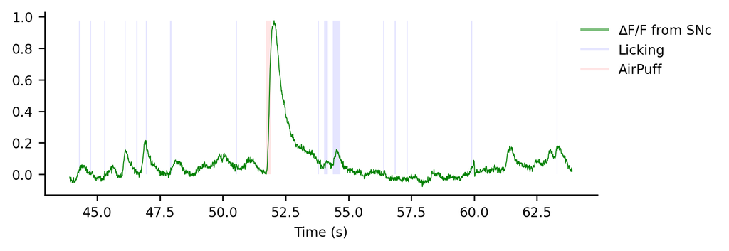

```python
import pandas as pd
from matplotlib import pyplot as plt
import matplotlib.lines as mlines

# Prepare data for plotting
data = df_over_f_traces.data[3000:5000, 0]
timestamps = df_over_f_traces.get_timestamps()[3000:5000]

fig, ax = plt.subplots(nrows=1, ncols=1, figsize=(6, 2), dpi=300, sharex=True)

# Plot the main data
ax.plot(timestamps, data, color="green", linewidth=0.5)

licking_events = events[events["event_type"] == "Licking"]
licking_events = licking_events[(licking_events["start_time"] >= timestamps[0]) & (licking_events["stop_time"] < timestamps[-1])]

airpuff_events = events[events["event_type"] == "AirPuff"]
airpuff_events = airpuff_events[(airpuff_events["start_time"] >= timestamps[0]) & (airpuff_events["stop_time"] < timestamps[-1])]

for ind, row in licking_events.iterrows():
    ax.fill_between(timestamps, max(data), where=(timestamps >= row["start_time"]) & (timestamps <= row["stop_time"]), color='blue', edgecolor='none', alpha=0.1)

for ind, row in airpuff_events.iterrows():
    ax.fill_between(timestamps, max(data), where=(timestamps >= row["start_time"]) & (timestamps <= row["stop_time"]), color='red', edgecolor='none', alpha=0.1)

ax.spines['top'].set_visible(False)
ax.spines['right'].set_visible(False)

# Create proxy lines for legend entries with corresponding colors and transparency
green_line = mlines.Line2D([], [], color='green', label='∆F/F from SNc', alpha=0.5)
blue_line = mlines.Line2D([], [], color='blue', label='Licking', alpha=0.1)
red_line = mlines.Line2D([], [], color='red', label='AirPuff', alpha=0.1)

# Set legends with proxy lines
ax.legend(handles=[green_line, blue_line, red_line], frameon=False, bbox_to_anchor=(.95, 1), loc='upper left', prop={'size': 8})

ax.tick_params(axis='y', labelsize=8)

plt.xlabel('Time (s)', fontsize=8)
plt.tick_params(axis='x', labelsize=8)
plt.show()
```

### Fluorescence peaks

The onset times of large fluorescence peaks are also stored in an `EventsTable` object using [`ndx-events`](https://github.com/rly/ndx-events) and can be accessed as `nwbfile.analysis["PeakFluorescenceEvents"]`. The id and the description of the events can be accessed as `nwbfile.analysis["PeakFluorescenceEventTypes"]`.

```python
import pandas as pd

peak_events = pd.merge(
    left=nwbfile.analysis["PeakFluorescenceEvents"][:],
    right=nwbfile.analysis["PeakFluorescenceEventTypes"][:],
    left_on="event_type",
    right_on="id",
)
peak_events.tail()
```

|  | timestamp | event_type | peak_fluorescence | event_name | event_type_description |
| --- | --- | --- | --- | --- | --- |
| 1101 | 1683.64 | 0 | 0.099074 | peaksG | Large transient peaks for Fiber 1 fluorescence |
| 1102 | 1685.67 | 0 | 0.058068 | peaksG | Large transient peaks for Fiber 1 fluorescence |
| 1103 | 1685.67 | 1 | 0.058068 | peaksGRun | Large transient peaks occurring during running... |
| 1104 | 1689.86 | 0 | 0.113421 | peaksG | Large transient peaks for Fiber 1 fluorescence |
| 1105 | 1689.86 | 1 | 0.113421 | peaksGRun | Large transient peaks occurring during running... |

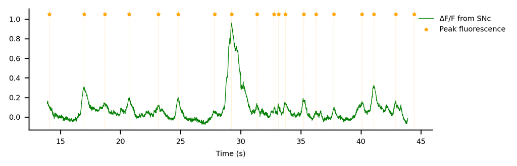

```python
import pandas as pd
from matplotlib import pyplot as plt

# Prepare data for plotting
data = df_over_f_traces.data[:3000, 0]
timestamps = df_over_f_traces.get_timestamps()[:3000]

# Add events during selected time
peak_event_times = peak_events[peak_events["event_type"] == 0]
peak_event_times = peak_event_times[peak_event_times["timestamp"] <= 45]["timestamp"]

fig, ax = plt.subplots(nrows=1, ncols=1, figsize=(6, 2), dpi=300, sharex=True)

# Plot the main data
data_handle, = ax.plot(timestamps, data, color="green", linewidth=0.5, label="∆F/F from SNc")

# Add vertical lines for events
for time in peak_event_times:
    ax.axvline(time, color='orange', linewidth=0.1, linestyle="--")

# Add scatter for peak events
arrowhead_size = 6  # Adjust this value to change the size of the arrowheads
peak_handle = ax.scatter(peak_event_times, [1.05] * len(peak_event_times), color='orange', marker='*', s=arrowhead_size, label='Peak fluorescence')

# Hide top and right spines
ax.spines['top'].set_visible(False)
ax.spines['right'].set_visible(False)

# Add legends
handles = [data_handle, peak_handle]
labels = ["∆F/F from SNc", "Peak fluorescence"]
ax.legend(handles, labels, frameon=False, bbox_to_anchor=(.95, 1), loc='upper left', prop={'size': 6})

# Adjust tick parameters
ax.tick_params(axis='y', labelsize=6)

plt.xlabel('Time (s)', fontsize=6)
plt.tick_params(axis='x', labelsize=6)
plt.tight_layout()
plt.show()
```

# View NWB

This section demonstrates how to use [Neurosift](https://github.com/flatironinstitute/neurosift) to interactively visualize the data in the NWBfile.

```python
from IPython.display import IFrame

url = "https://neurosift.app/?p=/nwb&url=https://api.dandiarchive.org/api/assets/9994f42b-fdbb-4938-a3a3-6add744bf169/download/&dandisetId=001038&dandisetVersion=draft&tab=neurodata-items:neurodata-item:/processing/ophys/DfOverFFiberPhotometryResponseSeries|FiberPhotometryResponseSeries@neurodata-item:/processing/ophys/DfOverFFiberPhotometryResponseSeriesIsosbestic|FiberPhotometryResponseSeries@neurodata-item:/processing/behavior/Velocity|TimeSeries"
IFrame(url, width=1200, height=1000)
```

[interactive chart not shown]